# Montana State University - Data Science Workshop

Data Carpentry contributors & MSU Data Science Workshops Team

August 14, 2026

# About

## Data Science Workshop, August 14, 9am - 5pm

Join us for an all-day workshop where you’ll learn to use the `R` programming language for data science applications. These concepts will be presented in an interactive format, integrating instruction and computational practice. Montana University system graduate students, undergrads, staff, faculty, and community members are all welcome to join. The full schedule is below.

**Location:** Montana State University, American Indian Hall (AIH) Room 166 - with an online option  
**Date:** Friday, August 14, 2026  
**Time:** 9 a.m. - 5 p.m.

### Introduction to `R` - 9-10:30am

Learn the basics of `R`, RStudio, and the Tidyverse.

### Break - 10:30-10:45am

### Introduction to `R` Continued - 10:45-11:30am

### Q&A - 11:30-Noon

### Lunch (provided) - 12-1:00pm

### Data Visualization in `R` - 1-2:30pm

Learn to visualize data in `R` using the ggplot2 package.

### Break - 2:30-2:45pm

### Coding with Generative AI - 2:45-4:30pm

Learn how to use Gen AI responsibly with hands-on coding and discussion.

### Q&A and Wrap-up - 4:30-5:00pm

The workshop is sponsored by the Library, Social Data Collection and Analysis Services, and Montana INBRE.

# Introduction to `R`

## Learning Objectives

> - Understand the RStudio user interface and know where to change default settings.
> - Know how to create or open an `R` package.
> - Know how to open an RMD file.
> - Know how to search for help in RStudio.
> - Know how to use the command line to use `R` as a calculator.
> - Load packages and understand the messages that result.
> - Import data and get a quick summary of the variables.
> - Extract, access, mutate, or summarize data from a dataframe.
> - Save a modified dataset for future use or documentation purposes.

## Getting Started

The term `R` is used to refer to both the programming language as well as the software that interprets the scripts written using it. The learning curve may be steeper than with other statistical software, but with `R` the results of your analysis or your plot does not rely on remembering what order you clicked on things, but instead on the written commands you generated. In `R` you will work in scripts or with dynamic documents, with scripts within them (Rmd or Rnw files). Scripts may feel strange at first, but they make the steps you used in your analysis clear for both you and for someone who wants to give you feedback, further promoting the importance of reproducible science!

RStudio is a free computer application that allows you access to the resources of `R`, while providing you with a comfortable working environment. There are many ways you can interact with `R`, but for many reasons RStudio has become the most popular. To function correctly, RStudio uses `R` behind the scenes, hence both need to be installed on your computer. Both `R` and `RStudio` are cross-platform, so that everyone’s versions look and operate the same regardless of their operating system!

For this workshop, we will be making use of RStudio which you will need to install on your computer.

1. First you will want to go to https://cran.r-project.org/ to download for your specific operating system, run the `R` installer that you downloaded and
2. then go to https://posit.co/download/rstudio-desktop/ to download and install RStudio.

For more assistance with getting set up, please check out the instructions provided by Data Carpentries at https://datacarpentry.org/R-ecology-lesson/#install-r-and-rstudio. You need to have a computer that is running Linux, Windows, or a somewhat recent macOS. Unfortunately, a Chromebook, iPad, Snapdragon, or other ARM type computers are not sufficient for installing and running R. If you have borrowed a computer from the library you will also not be able to install the necessary software.

**NOTE:** If you are unable to install the software there are online apps that allow you to run RStudio. You can try https://webr.sh to see if that works for you.

However you get to it, RStudio has four default panels, where each can be viewed at the same time and has multiple tabs available. The location of these tabs can be adjusted in the **View -> Panes -> Panes Layout…** section of the **Global Options** dialog, it is possible that your initial layout may be different than what is shown below. The content and function remains the same. (See Figure 1)

- the **Editor** for your scripts and documents (top-left - will be available once an RMD or script file is opened)
- the `R` **Console** (bottom-left)
- your **Environment (Objects/Variables)/History** (top-right)
- and your **Files/Plots/Packages/Help/Viewer** (bottom-right).

[figure not shown]

RStudio layout

You can use the **Tools -> Global Options -> Appearance** tab to modify the colors and font sizes in RStudio.

### Projects in `RStudio`

`R` projects provide a way to organize all the code and data in one place and many consider these the best way to work in `R`. A motivation for using projects is that it is important to organize your data and script files into the same or related locations and have different locations for different iterations of projects. If you don’t do this:

- it is really hard to tell which version of your data is original and what versions are modified
- things get really messy because all types of files are mixed together
- it’s probably hard for you to find things and relate the correct files to their respective output

Ultimately, good project organization will make your life easier! It helps ensure the integrity of your data, makes it simpler to share your code or get help with your code, allows for you know exactly what code you used on a paper, and it’s easier to pick a project back up.

It is good code writing and file storage practice to keep a set of all related data, analysis, plots, documents, etc. in the same folder. RStudio makes this process easy with using their projects. In an RStudio project, all of the project’s pieces are in the same folder. This allows for a clean workflow and a simple working directory for `R`. When you are executing code for a document/script `R` will search for things (such as data) in the folder as the document/script, which is called a *relative path*.

Whenever you start working on a new project in RStudio, go through the following steps:

1. Click on the “File” menu button, then select “New Project”
2. Click “New Directory”
3. Click “New Project”
4. Create a name for your project (make it explanatory!)
5. Select where the project should live
6. Click the “Create Project” button
7. Open the project!

After this process `R` will be searching for objects (such as data) in the folder as the project. This allows for us to keep all of our files in a self-contained system.

You can either create a project in a new folder, or the existing folder containing the workshop materials.

### Challenge 1:

Go ahead and create your first project! Create it in the **same directory** as the workshop files.

## Working in `R`

The document we provided for you is an Rmarkdown (.Rmd) document. It allows you to work in a reproducible fashion, with both code (placed in what are called code chunks) and descriptions of results in the same file. The grey sections that have three single quotes then `{r}` will delineate a code chunk.

````
```{r}
1 + 1
```
````

You can add these with Insert -> `R` into a .Rmd file. Type all of your code in these code chunks and other documentation and interpretation of results outside of the code chunks (like we are doing here).

Once we are done with our local work, we can also use the `Knit` button to compile our work into HTML, Word (DOCX), or PDF documents. We will demonstrate this at the end of the workshop - but this will only work if all the code “runs” and what we have provided you has some errors in it. One other feature we’ve come to expect in modern document editors is live spell-checknig - I mean spell-checking - by underlining suspect words, which RStudio does without flagging code and variable names.

RStudio allows for you to execute commands directly from the code chunk in the document by using the **Ctrl + Enter** (on Macs, **Cmd + Return**) shortcut. If you place your cursor on the line in the code chunk that you would like to run and hit this shortcut, `R` will execute that line(s) of code for you. Alternatively, you can also execute code in the console (where the output of the commands pops up). The difference between running code in the console and in the document is that any code you execute in the console will be lost once you close your `R` session. If you type code into the document’s code chunks, it will be saved when you close your `R` session. Because we want to be able to go back and re-run our code at the end of the session, it is better to type the command we want `R` to run in the document and save it!

If `R` is ready to accept commands, the `R` console (in the bottom-left) will show a `>` prompt. When `R` receives a command (by typing, copy-pasting, or using the shortcut), it will execute it, and when finished will display the results and show the `>` symbol once again. If `R` is still waiting for you to provide it with additional instructions, a `+` will appear in the console. This should tell you that you didn’t finish your command. You could have forgotten to close your parenthesis or a quotation. If this happens and you are unsure of what went wrong, click inside the console and hit the `Esc` key. Then you can start over and figure out where you went wrong!

### Calculator

**Practice**: Enter each of the following commands and confirm that the response is the correct answer. Try to do this in the console and by executing the code in the code chunk, both line by line and all at once.

```r
1 + 2
```

```
## [1] 3
```

```r
16*9
```

```
## [1] 144
```

```r
sqrt(2)
```

```
## [1] 1.414214
```

## Creating Objects

These operations, however, are not very interesting. To do more useful things in `R`, we need to assign values to an object. To create an object, we tell `R` the object’s name, followed by an assignment arrow (`<-`), and finally the value of the object. This would look something like this:

`year <- 2026`

Once we execute/run this line of code, we notice that a new object appears in our environment window. This window shows all of the objects that you have created during your `R` session. The value of `year` appears next to it, since it is a scalar (single number as opposed to a set of numbers or a set of a set of numbers).

**Remarks:**

- In the above code `<-` is the assignment operator. It assigns values on the right to objects on the left. So, after executing `year <- 2026`, the value of `year` is `2026`. The arrow can be read as “`2026` goes into `year`”. For historical reasons, you can also use `=` for assignments, but not in every context. Because of the slight differences in syntax, it is best practice to always use `<-` for assignments.
  - In RStudio, typing `Alt` at the same time as the `-` key will write `<-` in a single keystroke. Neat! (`Option` + `-` on MacOS)
- There are a few simple rules that apply when creating the same of a new object (like we did above):
  - `R` is case sensitive, so if you name your variable `cat` but then try to run the code `Cat + 2`, you will get an error saying that `Cat` does not exist
  - You also want your object’s name to be explanatory, but not too long. Think `current_temperature` verses `current_temp`. Do you really want to type out temperature every time?
  - Finally, you cannot begin any object’s name with a number. You can end a name with a number (e.g., `clean_data2`), but does that give you much information about what is in the contents of `clean_data2` relative to `clean_data`?
  - The name cannot contain any punctuation symbols, except for `.` and `_` (note `.` is not recommended)
  - You should not name your object the same as any common functions you may use (`mean`, `sd,` etc.)
- Using a consistent coding style makes your code clearer to read for your future self and your collaborators.

## Order matters and checking values

When you assign a value to an object `R` does not output anything by default. Writing the name of the object will output the value of the object you created.

```r
year <- 2026

year
```

```
## [1] 2026
```

Once the object `year` has been created, you can use it! Run the following lines of code:

```r
2.2 * year
```

```
## [1] 4457.2
```

```r
4 + year
```

```
## [1] 2030
```

We can also overwrite an object’s value, so that it has a new value. In the code below create a new object `another_year` and then we give `year` a new value of 2030.

```r
another_year <-  year + 6

year <- 2030
```

### Exercise 1:

What is the current value of `another_year`? 2032 or 2036?

1. Create a code chunk (Hint, use **Ctrl + Alt + I** on Windows, or **Cmd + Option + I** on Mac, to insert a blank `R` code chunk), and
2. Write the code to display the value of the object.

*Insert your code chunk here.*

## Motivating Research Questions

To give context to the workshop we are going to put ourselves in the role of a biologist or ecologist studying the health and abundance of fish in the Blackfoot river. We’ve already done the hard work of going out and collecting the data, now we are ready to analyze it.

### Research Questions

Descriptive questions include:

1. Summarize the health of the fish caught in this project in tables and graphs by year caught, length, weight, and species.

Inferential questions include:

1. The mean length of a Westslope Cutthroat Trout is different in different sections of the Blackfoot River.

## Examine collected data

**CAUTION:** For some types of data, including long text in cells and dates, opening the file in Excel can modify the data in unexpected ways. You can fix those problems after importing into `R`, but it is something to be aware of and check before analyzing data.

*Advanced:* Import this file into RStudio and explore the data.

We will keep these research questions and idea of the data in mind as we work through answering the questions in `R` using RStudio.

[figure not shown]

Blackfoot Fish data in Excel

## Packages

`R` has many packages, which people around the world work on to provide and maintain new software and new capabilities for `R`. You will slowly accumulate a number of packages that you use often for a variety of purposes. In order to use the elements (data, functions) of the packages, you have to first install the package (only once on a given computer) and then load the package (every time).

We’re going to install a packages that is actually a collection of packages that are often used.

- Use the **Install** button in the **Packages** tab
- Type in `tidyverse` into the blank line
- Check the **Install dependencies** box
- Click on the **Install** button

There will be a large amount of output coming out of the console. This output is `R` trying to download the package(s) you requested. Once the computer has downloaded the packages, it will tell you that “`The downloaded binary packages are in`”, followed by the location of the files.

Now that the files are downloaded, we need to load the package in order to use it. The following code will load all of the packages in the “tidyverse”, please run it!

```r
library(tidyverse)
```

### Why use the “tidyverse”?

The **`tidyverse`** package tries to address 3 common issues that arise when doing data analysis with some of the functions that come with `R`:

1. The results from a base `R` function sometimes depend on the type of data.
2. Using `R` expressions in a non-standard way, which can be confusing for new learners.
3. Hidden arguments, having default operations that new learners are not aware of.

This is the process you go through if you ever find packages that you would like to use! Often packages that you install will need to be updated. To update a package you can click on the “Tools” tab, then click on “Check for Package Updates”. This will bring up a window that will list all of the packages that have newer versions than what you have. Click on the packages that you wish to update, or click on the “Select All” button.

> *ERROR ALERT* If you ever get an error updating a package, do the following:
> 1. Take a note of the name,
> 2. navigate to where your packages are saved,
> 3. close RStudio,
> 4. delete the folder for that package,
> 5. restart RStudio, and
> 6. install that package again.

## Finding Help

One of the chief reasons for `R`’s religious following is its wonderful documentation. If you need a function to complete a task (say find the variance), but are not quite sure how it’s spelled, what arguments it takes, or what package it lives in, don’t fret! The `?` and `help()` commands are very powerful. For functions, placing the `?` before the name, will tell `R` to search for that name in all of the functions, in all of the packages you have installed.

- If it finds *one* **identical match**, it will display the help file for that function in the Help tab in the bottom-right corner.
- If it finds *more than one* **identical match**, it will display the functions, in their respective packages, that you have to choose from.
- If it finds *no* **identical match**, it will tell you that “`No documentation for ____ in specified packages and libraries:,`” and suggests you use a `??` instead.
  - A `??` in front of the function name will search **all of `R`** for named functions similar to what you typed.
  - The output will tell you what package the function is in, as well as the function’s name (`package::function`).

If you would like help on a particular package, say one that you just downloaded, then you can use the same command(s) to get help. These commands will load up a help page (in RStudio) in the Help pane. Each help page is broken down into sections:

- Description: An extended description of what the function does.
- Usage: The arguments of the function and their default values.
- Arguments: An explanation of the object each argument is expecting.
- Details: Any important details to be aware of.
- Value: The object the function returns.
- See Also: Any related functions that may be useful.
- Examples: Some examples for how to use the function.

## Importing Data

- Use the **Import Dataset** button in the **Environment** tab
- Choose the **From Text (readr)** option
- Click on the **Browse** button
- Direct the computer to where you saved the `BlackfootFish.csv` data file, click **open**
- It will bring up a preview of the data
- Click on the **Import** button

Notice the code that outputs in the console (the bottom left square). This is the code that you could have typed in the code chunk below to import the data yourself. Copy and paste the code that was output in the code chunk below.

```r
# copy and paste the code that was used by R to import the data
# be careful to only copy the code that is next to the > signs!
```

```r
BlackfootFish <- read_csv("data/BlackfootFish.csv")
```

> *ERROR ALERT* At this point, if you are having any errors, it is likely due to working in a zipped folder. Fix this by doing the following:
> 1. In a file browser, navigate to where you downloaded the workshop materials,
> 2. right click on the folder and extract to a new location such as your desktop,
> 3. open the RMD file in the extracted folder by double clicking on it, it should open in RStudio.

## Working with Different Data Types

A vector is the basic data type in `R`. A vector is a series of values, which can be either numbers or characters, but every entry of the vector must be the same data type. `R` can tell that you are building a vector when you use the `c()` function, which concatenates a series of entries together.

```r
temps <- c(50, 55, 60, 65)
temps
```

```
## [1] 50 55 60 65
```

To make a vector of characters, you are required to use quotation marks (`" "`) to indicate to `R` that the value you are using is not an object you already created in `R`.

```r
animals <- c("cat", "dog", "bird", "fish")
animals
```

```
## [1] "cat"  "dog"  "bird" "fish"
```

Important features of a vector is the type of data they store. Run the following lines of code and decide what type of data the vectors contain.

```r
class(temps)
```

```
## [1] "numeric"
```

```r
class(animals)
```

```
## [1] "character"
```

### Exercise 2:

1. Create a vector, named `dec`, that contains three decimal valued numbers.
2. Check: What data type does that vector contain?

```r
# Exercise 2 code here!
```

Another possible data type is a logical (Boolean) value. This type of data  
takes on values of `TRUE` and `FALSE`. But, we said that vectors could only be numbers or characters. If `TRUE` and `FALSE` don’t have quotations around them, then they aren’t characters. So, then they must be numbers. What numbers do you think they are?

```r
logic <- c(TRUE, FALSE, FALSE, TRUE)

class(logic)
```

```
## [1] "logical"
```

### Exercise 3:

What happens when we try to mix different data types into one vector? Speculate what will happen when we run each of the following lines of code:

```r
num_char <- c(1, 2, 3, "a")

num_logic <- c(1, 2, 3, FALSE)

char_logic <- c("a", "b", "c", TRUE)

guess <- c(1, 2, 3, "4")
```

In each of these vectors, the two types of data were *coerced* into a single data type. This happens in a hierarchy, where some data types get preference over others. Can we draw a diagram of the hierarchy?

## Structure of Data

The data we will use is organized into data tables. When you imported the `BlackfootFish` data into RStudio it was saved as an object. You are able to inspect the structure of the `BlackfootFish` object using functions.

Run the following code. What is output from each of the following commands?

```r
class(BlackfootFish) ## What is the object class of the data?
```

```
## [1] "spec_tbl_df" "tbl_df"      "tbl"         "data.frame"
```

```r
dim(BlackfootFish) ## What is the first number represent? What about the second number?
```

```
## [1] 18352     7
```

```r
names(BlackfootFish) ## What does this output refer to?
```

```
## [1] "trip"    "mark"    "length"  "weight"  "year"    "section" "species"
```

```r
str(BlackfootFish) ## What is the structure of the data?
```

```
## spc_tbl_ [18,352 × 7] (S3: spec_tbl_df/tbl_df/tbl/data.frame)
##  $ trip   : num [1:18352] 1 1 1 1 1 1 1 1 1 1 ...
##  $ mark   : num [1:18352] 0 0 0 0 0 0 0 0 0 0 ...
##  $ length : num [1:18352] 288 288 285 322 312 363 269 160 213 157 ...
##  $ weight : num [1:18352] 175 190 245 275 300 380 170 40 80 35 ...
##  $ year   : num [1:18352] 1989 1989 1989 1989 1989 ...
##  $ section: chr [1:18352] "Johnsrud" "Johnsrud" "Johnsrud" "Johnsrud" ...
##  $ species: chr [1:18352] "RBT" "RBT" "RBT" "RBT" ...
##  - attr(*, "spec")=
##   .. cols(
##   ..   trip = col_double(),
##   ..   mark = col_double(),
##   ..   length = col_double(),
##   ..   weight = col_double(),
##   ..   year = col_double(),
##   ..   section = col_character(),
##   ..   species = col_character()
##   .. )
##  - attr(*, "problems")=<pointer: 0x0000023c831f1ad0>
```

```r
summary(BlackfootFish) ## What is the data type of each variable in our dataset?
```

```
##       trip            mark             length          weight
##  Min.   :1.000   Min.   :0.00000   Min.   : 16.0   Min.   :   0.0
##  1st Qu.:1.000   1st Qu.:0.00000   1st Qu.:186.0   1st Qu.:  65.0
##  Median :2.000   Median :0.00000   Median :250.0   Median : 150.0
##  Mean   :1.501   Mean   :0.09285   Mean   :262.3   Mean   : 246.2
##  3rd Qu.:2.000   3rd Qu.:0.00000   3rd Qu.:330.0   3rd Qu.: 330.0
##  Max.   :2.000   Max.   :1.00000   Max.   :986.0   Max.   :4677.0
##                                                    NAs    :1796
##       year           section           species
##  Min.   :1989   Length   :18352   Length   :18352
##  1st Qu.:1991   N.unique :    2   N.unique :    4
##  Median :1996   N.blank  :    0   N.blank  :    0
##  Mean   :1997   Min.nchar:    8   Min.nchar:    3
##  3rd Qu.:2002   Max.nchar:   11   Max.nchar:    5
##  Max.   :2006
##
```

```r
typeof(BlackfootFish) ## What is the storage mode of a data.frame?
```

```
## [1] "list"
```

For more information about “lists” see the Appendix.

When we inspect dataframes, or other objects in `R`, there are some general functions that are useful to check the content/structure of the data. Here are some:

- size:
  - `dim(datasetname)`: rows and columns
  - `nrow(datasetname)`: number of rows
  - `ncol(datasetname)`: number of columns
  - `length(datasetname$variable)`: length of a vector
- content:
  - `head(datasetname)`: first 6 rows
  - `tail(datasetname)`: last 6 rows
  - `View(datasetname)`: opens viewer window in separate tab
- names:
  - `colnames(datasetname)`: column names of dataframe
  - `rownames(datasetname)`: row names of dataframe
- summary of content:
  - `str(datasetname)`: structure of object and information about the columns
  - `glimpse(datasetname)`: similar information to `str`, but neater output (requires `tibble` package)
  - `summary(datasetname)`: summary statistics for each column

*Note:* Many of these are generic functions that will work on other data types, not just on `data.frame`s.

## Dataframes

What is a dataframe? A dataframe (also called a “tibble” when created by the `tidyverse` package) is a type of `R` object and is the *de facto* structure of tabular data. You can create dataframes by hand, but most of us do not use `R` to input our data by hand. Instead, we import our data using `R` commands that read in spreadsheets (`read.csv`, `read_csv` (requires `readr` which is one of the packages imported by the `tidyverse` package), `read_excel` (requires `readxl` package), etc.). A dataframe is a set of columns, where each column is a vector. Thus, columns have the same data type *within* the column, but potentially different data types *across* columns.

## Extracting Data

If we were interested in accessing a specific variable in our dataset, we can use the `$` command. This command extracts the specified variable (on the right of the `$` sign) from the dataset. When this is extracted, `R` views the variable as a vector of entries, which is what the [1:18352] refers to.

```r
years <- BlackfootFish$year
## extracts year from the dataset and saves it into a new variable named years

str(years) ## using the new variable (remember case matters!)
```

```
##  num [1:18352] 1989 1989 1989 1989 1989 ...
```

```r
## How would you determine how long the vector is?
```

Another method for accessing data in the dataset is using matrix notation ([row, column]). If you look to your right in the **Environment** window, you notice that RStudio tells you the dimensions of the `BlackfootFish` data. You can (roughly) view the dataset as a matrix of entries, with variable names for each of the columns. I could instead use bracket notation to perform the same task as above, using the following code.

```r
years <- BlackfootFish[, 5]
## This takes ALL rows of data but only the fifth column
## Same as years <- BlackfootFish[1:18352, 5]

BlackfootFish[1, 5]
```

```
## # A tibble: 1 × 1
##    year
##   <dbl>
## 1  1989
```

```r
str(years)
```

```
## tibble [18,352 × 1] (S3: tbl_df/tbl/data.frame)
##  $ year: num [1:18352] 1989 1989 1989 1989 1989 ...
```

### Practice: Working with dataframes

The following is a preview of the dataframe `df`:

```r
df <- data.frame(
  x = c("H", "N", "T", "W", "V"),
  y = c("May", "Oct", "Mar", "Aug", "Feb"),
  z = c(2010, 2015, 2018, 2017, 2019)
  )

df
```

```
##   x   y    z
## 1 H May 2010
## 2 N Oct 2015
## 3 T Mar 2018
## 4 W Aug 2017
## 5 V Feb 2019
```

#### Exercise 4:

What would be output if you entered: `df[3, ]`?

#### Exercise 5:

What would you input to get an output of `2015`? Can you think of two ways to do it?

### Accessing Data

When we have a data frame or a list of objects, we can extract specific items by specifying their position in the data frame or list. We saw how to do this with a single item, row, or column that we want to extract (`BlackfootFish[1, 5]`, `df[3,]` or `BlackfootFish[, 5]`). We can specify two items, rows, or columns by either using the fact that the two things we want are adjacent, or we can combine what we want into a list that we can then use for extracting. We will continue to use the indices to specify what we want to extract.

For example, `c(1, 2)` could identify the first two objects in a list. However they are adjacent so we could use `a:b` to indicate that we want everything from position `a` to position `b` in the list. So, `c(1,2)` would give the same items as `c(1:2)`.

#### Quick Check

Run the following code to see what you get. Play around with the first and last numbers to see what happens.

```r
c(1, 2, 3, 4, 5)
```

```
## [1] 1 2 3 4 5
```

```r
c(1:5)
```

```
## [1] 1 2 3 4 5
```

```r
c(5:1)
```

```
## [1] 5 4 3 2 1
```

```r
c(123:131)
```

```
## [1] 123 124 125 126 127 128 129 130 131
```

```r
c(3:-1)
```

```
## [1]  3  2  1  0 -1
```

When you want adjacent items, using the `a:b` notation is nicer than having to type out all of the values.

*What about non-adjacent items?*

For non-adjacent items, you just need to fall back on listing everything out. Say you want the first, third, and 9th item in a list. Then you can use `c(1, 3, 9)`.

Now that we’ve talked about how to create lists of the indices we want, how do we use these lists to extract items?

Using our data frame that we created above, to extract rows 2 and 3 we can use the notation `c(2, 3)` (or `c(2:3)` since they are adjacent).

```r
df[c(2,3), ]
```

```
##   x   y    z
## 2 N Oct 2015
## 3 T Mar 2018
```

If we want to extract rows 2 and 4, we can use this list of indices: `c(2, 4)`

```r
df[c(2,4),]
```

```
##   x   y    z
## 2 N Oct 2015
## 4 W Aug 2017
```

*NOTE:* Instead of using indices you can also do the same technique with names if the rows or columns are named.

#### Exercise 6:

1. How would you pull off only columns `x` and `y`?
2. What about pulling off only columns `x` and `z`?

#### Exercise 7:

How would you modify the script below, to get an output of `[1] 22 24`?

```r
s <- c(22, 24, 49, 18, 1, 6)
s[]
```

#### Exercise 8:

See what would happen if you entered `s[3, ]`. How can you explain that result?

### Piping Data In

Most functions require data to operate on. Because of this, the first argument to many functions is the dataset you wish to be working with. The pipe operator sends the output of one function directly into the next function, which is useful when you need to do many things to the same dataset.

Pipes in `R` look like `|>`, there is also a pipe that looks like `%>%` from the **`magrittr`** package, installed automatically with the **`tidyverse`**. If you use RStudio, you can type the pipe with `Ctrl + Shift + M` if you have a PC, or `Cmd + Shift + M` if you have a Mac. In the settings (Tools > Global Options > Code) you can change the pipe operator that is inserted when you use those short cuts.

**NOTE:** Generally native operators are preferred over those that require packages, although there are many more piping operators available in the `magrittr` package for those that are interested in digging deeper.

One function we used previously was the `summary()` function. This function uses a dataset as its only parameter. This is how to call that function when using piping to pass in the dataset.

```r
BlackfootFish |>
  summary()
```

```
##       trip            mark             length          weight
##  Min.   :1.000   Min.   :0.00000   Min.   : 16.0   Min.   :   0.0
##  1st Qu.:1.000   1st Qu.:0.00000   1st Qu.:186.0   1st Qu.:  65.0
##  Median :2.000   Median :0.00000   Median :250.0   Median : 150.0
##  Mean   :1.501   Mean   :0.09285   Mean   :262.3   Mean   : 246.2
##  3rd Qu.:2.000   3rd Qu.:0.00000   3rd Qu.:330.0   3rd Qu.: 330.0
##  Max.   :2.000   Max.   :1.00000   Max.   :986.0   Max.   :4677.0
##                                                    NAs    :1796
##       year           section           species
##  Min.   :1989   Length   :18352   Length   :18352
##  1st Qu.:1991   N.unique :    2   N.unique :    4
##  Median :1996   N.blank  :    0   N.blank  :    0
##  Mean   :1997   Min.nchar:    8   Min.nchar:    3
##  3rd Qu.:2002   Max.nchar:   11   Max.nchar:    5
##  Max.   :2006
##
```

We’re going to learn some of the most common functions used to wrangle data:

- `select()`: subset columns
- `filter()`: subset rows on conditions
- `mutate()`: create new columns by using information from other columns
- `group_by()` and `summarize()`: create summary statistics on grouped data
- `arrange()`: sort results
- `count()`: count discrete values

## Select, Filter, and Mutate

### Selecting Columns and Filtering Rows

To select columns of a data frame, use `select()`. The first argument to this function is the data frame (`BlackfootFish`), and the subsequent arguments are the columns to keep.

The following code selects the `length`, `weight`, and `species` columns from the `BlackfootFish` dataset:

```r
BlackfootFish |>
  select(length, weight, species)
```

```
## # A tibble: 18,352 × 3
##    length weight species
##     <dbl>  <dbl> <chr>
##  1    288    175 RBT
##  2    288    190 RBT
##  3    285    245 RBT
##  4    322    275 RBT
##  5    312    300 RBT
##  6    363    380 RBT
##  7    269    170 RBT
##  8    160     40 RBT
##  9    213     80 RBT
## 10    157     35 RBT
## # ℹ 18,342 more rows
```

To select all columns *except* certain ones, put a “-” in front of the variable to exclude it.

The following code selects all columns *except* `trip` and `mark`:

```r
BlackfootFish |>
  select(-trip, -mark)
```

```
## # A tibble: 18,352 × 5
##    length weight  year section  species
##     <dbl>  <dbl> <dbl> <chr>    <chr>
##  1    288    175  1989 Johnsrud RBT
##  2    288    190  1989 Johnsrud RBT
##  3    285    245  1989 Johnsrud RBT
##  4    322    275  1989 Johnsrud RBT
##  5    312    300  1989 Johnsrud RBT
##  6    363    380  1989 Johnsrud RBT
##  7    269    170  1989 Johnsrud RBT
##  8    160     40  1989 Johnsrud RBT
##  9    213     80  1989 Johnsrud RBT
## 10    157     35  1989 Johnsrud RBT
## # ℹ 18,342 more rows
```

To choose rows based on a specific criteria, use `filter()`:

```r
BlackfootFish |>
  filter(year==1998)
```

```
## # A tibble: 1,320 × 7
##     trip  mark length weight  year section  species
##    <dbl> <dbl>  <dbl>  <dbl> <dbl> <chr>    <chr>
##  1     1     0    242    120  1998 Johnsrud RBT
##  2     1     0    220     90  1998 Johnsrud RBT
##  3     1     0    210     80  1998 Johnsrud RBT
##  4     1     0    192     60  1998 Johnsrud RBT
##  5     1     0    395    480  1998 Johnsrud RBT
##  6     1     0    370    410  1998 Johnsrud RBT
##  7     1     0    235    130  1998 Johnsrud RBT
##  8     1     0    222    110  1998 Johnsrud RBT
##  9     1     0    185     55  1998 Johnsrud RBT
## 10     1     0    252    170  1998 Johnsrud RBT
## # ℹ 1,310 more rows
```

In the code above `==` keeps all rows where the year is 1998.

Other filtering options include `!=`, which keeps all rows that are **not** a certain criteria, `,` which means **“and”**, and `|` which means **“or”**. Filter can also do `<` for “less than”, `>` for “greater than”, `<=` for “less than or equal to”, and `>=` for “greater than or equal to”. We type these last two options the same way we would typically say them.

1. `!=` example:

```r
BlackfootFish |>
  filter(year!=1998)
```

```
## # A tibble: 17,032 × 7
##     trip  mark length weight  year section  species
##    <dbl> <dbl>  <dbl>  <dbl> <dbl> <chr>    <chr>
##  1     1     0    288    175  1989 Johnsrud RBT
##  2     1     0    288    190  1989 Johnsrud RBT
##  3     1     0    285    245  1989 Johnsrud RBT
##  4     1     0    322    275  1989 Johnsrud RBT
##  5     1     0    312    300  1989 Johnsrud RBT
##  6     1     0    363    380  1989 Johnsrud RBT
##  7     1     0    269    170  1989 Johnsrud RBT
##  8     1     0    160     40  1989 Johnsrud RBT
##  9     1     0    213     80  1989 Johnsrud RBT
## 10     1     0    157     35  1989 Johnsrud RBT
## # ℹ 17,022 more rows
```

The code above keeps all rows where the year is not 1998.

2. `,` example:

```r
BlackfootFish |>
  filter(year==1998, species=="WCT") # can also use "&" instead of a comma
```

```
## # A tibble: 263 × 7
##     trip  mark length weight  year section  species
##    <dbl> <dbl>  <dbl>  <dbl> <dbl> <chr>    <chr>
##  1     1     0    280    215  1998 Johnsrud WCT
##  2     1     0    215     80  1998 Johnsrud WCT
##  3     1     0    232    120  1998 Johnsrud WCT
##  4     1     0    240    120  1998 Johnsrud WCT
##  5     1     0    228    370  1998 Johnsrud WCT
##  6     1     0    320    380  1998 Johnsrud WCT
##  7     1     0    306    280  1998 Johnsrud WCT
##  8     1     0    292    260  1998 Johnsrud WCT
##  9     1     0    286    275  1998 Johnsrud WCT
## 10     1     0    316    350  1998 Johnsrud WCT
## # ℹ 253 more rows
```

The code above keeps all rows where the year is 1998 for Westslope Cutthroat Trout, i.e., year 1998 and species WCT. The rows meet **both** of these criteria.

3. `|` example:

```r
BlackfootFish |>
  filter(year==1998 | species=="WCT")
```

```
## # A tibble: 3,344 × 7
##     trip  mark length weight  year section  species
##    <dbl> <dbl>  <dbl>  <dbl> <dbl> <chr>    <chr>
##  1     1     0    242    120  1998 Johnsrud RBT
##  2     1     0    220     90  1998 Johnsrud RBT
##  3     1     0    210     80  1998 Johnsrud RBT
##  4     1     0    192     60  1998 Johnsrud RBT
##  5     1     0    395    480  1998 Johnsrud RBT
##  6     1     0    370    410  1998 Johnsrud RBT
##  7     1     0    235    130  1998 Johnsrud RBT
##  8     1     0    222    110  1998 Johnsrud RBT
##  9     1     0    185     55  1998 Johnsrud RBT
## 10     1     0    252    170  1998 Johnsrud RBT
## # ℹ 3,334 more rows
```

The code above keeps all rows where the year is 1998 **or** is a Westslope Cutthroat Trout, i.e., year 1998 or species WCT. The rows meet **either** of these criteria but do not have to meet not both.

4. `<` example:

```r
BlackfootFish |>
  filter(weight < 200)
```

```
## # A tibble: 9,615 × 7
##     trip  mark length weight  year section  species
##    <dbl> <dbl>  <dbl>  <dbl> <dbl> <chr>    <chr>
##  1     1     0    288    175  1989 Johnsrud RBT
##  2     1     0    288    190  1989 Johnsrud RBT
##  3     1     0    269    170  1989 Johnsrud RBT
##  4     1     0    160     40  1989 Johnsrud RBT
##  5     1     0    213     80  1989 Johnsrud RBT
##  6     1     0    157     35  1989 Johnsrud RBT
##  7     1     0    143     35  1989 Johnsrud RBT
##  8     1     0    179     70  1989 Johnsrud RBT
##  9     1     0    199    100  1989 Johnsrud RBT
## 10     1     0    196     95  1989 Johnsrud RBT
## # ℹ 9,605 more rows
```

The code above keeps all rows where weight is less than 200.

5. `>` example:

```r
BlackfootFish |>
  filter(length > 300)
```

```
## # A tibble: 5,863 × 7
##     trip  mark length weight  year section  species
##    <dbl> <dbl>  <dbl>  <dbl> <dbl> <chr>    <chr>
##  1     1     0    322    275  1989 Johnsrud RBT
##  2     1     0    312    300  1989 Johnsrud RBT
##  3     1     0    363    380  1989 Johnsrud RBT
##  4     1     0    345    395  1989 Johnsrud RBT
##  5     1     0    318    295  1989 Johnsrud RBT
##  6     1     0    378    485  1989 Johnsrud RBT
##  7     1     0    380    455  1989 Johnsrud RBT
##  8     1     0    312    270  1989 Johnsrud RBT
##  9     1     0    309    250  1989 Johnsrud RBT
## 10     1     0    312    270  1989 Johnsrud RBT
## # ℹ 5,853 more rows
```

The code above keeps all rows where length is greater than 300.

### Perform multiple functions on the same dataset

What if you want to select and filter at the same time?

```r
BlackfootFish |>
  filter(weight < 200) |>
  select(species, length, weight)
```

```
## # A tibble: 9,615 × 3
##    species length weight
##    <chr>    <dbl>  <dbl>
##  1 RBT        288    175
##  2 RBT        288    190
##  3 RBT        269    170
##  4 RBT        160     40
##  5 RBT        213     80
##  6 RBT        157     35
##  7 RBT        143     35
##  8 RBT        179     70
##  9 RBT        199    100
## 10 RBT        196     95
## # ℹ 9,605 more rows
```

As a refresher, in the above code, we use the pipe to send the `BlackfootFish` dataset first through `filter()` to keep rows where `weight` is less than 200, then through `select()` to keep only the `species`, `length`, and `weight` columns. Since `|>` takes the object on its left and passes it as the first argument to the function on its right, we don’t need to explicitly include the data frame as an argument to the `filter()` and `select()` functions.

Some may find it helpful to read the pipe like the word “then”. For instance, in the above example, we took the data frame `BlackfootFish`, *then* we `filter`ed for rows with `weight < 200`, *then* we `select`ed columns `species`, `length`, and `weight`. The functions by themselves are somewhat simple, but by combining them into linear workflows with the pipe, we can accomplish more complex wrangling of data frames.

If we want to create a new object with this smaller version of the data, we can assign it a new name:

```r
BlackfootFish_sml <- BlackfootFish |>
  filter(weight < 200) |>
  select(species, length, weight)

BlackfootFish_sml
```

```
## # A tibble: 9,615 × 3
##    species length weight
##    <chr>    <dbl>  <dbl>
##  1 RBT        288    175
##  2 RBT        288    190
##  3 RBT        269    170
##  4 RBT        160     40
##  5 RBT        213     80
##  6 RBT        157     35
##  7 RBT        143     35
##  8 RBT        179     70
##  9 RBT        199    100
## 10 RBT        196     95
## # ℹ 9,605 more rows
```

Note that the final data frame is the leftmost part of this expression.

#### Challenge 2

> Using pipes, subset the `BlackfootFish` data to include:
> - fish collected on or after 2002 and
> - retain only the columns `year`, `species`, `length`, and `weight`.

```r
## Pipes Challenge:
##  Using pipes, subset the data to include animals collected
##  on or after 2002, and retain the columns `year`, `species`, `length`, and `weight`
```

### Mutate

Frequently you’ll want to create new columns based on the values in existing columns, for example to do unit conversions, or to find the ratio of values in two columns. For this we’ll use `mutate()`.

To create a new column of weight in kg from weight in grams:

```r
BlackfootFish |>
  mutate(weight_kg = weight / 1000)
```

```
## # A tibble: 18,352 × 8
##     trip  mark length weight  year section  species weight_kg
##    <dbl> <dbl>  <dbl>  <dbl> <dbl> <chr>    <chr>       <dbl>
##  1     1     0    288    175  1989 Johnsrud RBT         0.175
##  2     1     0    288    190  1989 Johnsrud RBT         0.19
##  3     1     0    285    245  1989 Johnsrud RBT         0.245
##  4     1     0    322    275  1989 Johnsrud RBT         0.275
##  5     1     0    312    300  1989 Johnsrud RBT         0.3
##  6     1     0    363    380  1989 Johnsrud RBT         0.38
##  7     1     0    269    170  1989 Johnsrud RBT         0.17
##  8     1     0    160     40  1989 Johnsrud RBT         0.04
##  9     1     0    213     80  1989 Johnsrud RBT         0.08
## 10     1     0    157     35  1989 Johnsrud RBT         0.035
## # ℹ 18,342 more rows
```

You can also create a second new column based on the first new column within the same call of `mutate()`:

```r
BlackfootFish |>
  mutate(weight_kg = weight / 1000,
         weight_lb = weight_kg * 2.2)
```

```
## # A tibble: 18,352 × 9
##     trip  mark length weight  year section  species weight_kg weight_lb
##    <dbl> <dbl>  <dbl>  <dbl> <dbl> <chr>    <chr>       <dbl>     <dbl>
##  1     1     0    288    175  1989 Johnsrud RBT         0.175     0.385
##  2     1     0    288    190  1989 Johnsrud RBT         0.19      0.418
##  3     1     0    285    245  1989 Johnsrud RBT         0.245     0.539
##  4     1     0    322    275  1989 Johnsrud RBT         0.275     0.605
##  5     1     0    312    300  1989 Johnsrud RBT         0.3       0.66
##  6     1     0    363    380  1989 Johnsrud RBT         0.38      0.836
##  7     1     0    269    170  1989 Johnsrud RBT         0.17      0.374
##  8     1     0    160     40  1989 Johnsrud RBT         0.04      0.088
##  9     1     0    213     80  1989 Johnsrud RBT         0.08      0.176
## 10     1     0    157     35  1989 Johnsrud RBT         0.035     0.077
## # ℹ 18,342 more rows
```

If this runs off your screen and you just want to see the first few rows, you can use a pipe to view the `head()` of the data.

```r
BlackfootFish |>
  mutate(weight_kg = weight / 1000,
         weight_lb = weight_kg * 2.2) |>
  head()
```

```
## # A tibble: 6 × 9
##    trip  mark length weight  year section  species weight_kg weight_lb
##   <dbl> <dbl>  <dbl>  <dbl> <dbl> <chr>    <chr>       <dbl>     <dbl>
## 1     1     0    288    175  1989 Johnsrud RBT         0.175     0.385
## 2     1     0    288    190  1989 Johnsrud RBT         0.19      0.418
## 3     1     0    285    245  1989 Johnsrud RBT         0.245     0.539
## 4     1     0    322    275  1989 Johnsrud RBT         0.275     0.605
## 5     1     0    312    300  1989 Johnsrud RBT         0.3       0.66
## 6     1     0    363    380  1989 Johnsrud RBT         0.38      0.836
```

The dataset contains some missing observations (`NA`s). If we wanted to remove any observations where there were missing values on `weight`, we could insert a `filter()` in the chain:

```r
BlackfootFish |>
  filter(!is.na(weight)) |>
  mutate(weight_kg = weight / 1000,
         weight_lb = weight_kg * 2.2) |>
  summary()
```

```
##       trip           mark       length          weight            year
##  Min.   :1.00   Min.   :0   Min.   : 16.0   Min.   :   0.0   Min.   :1989
##  1st Qu.:1.00   1st Qu.:0   1st Qu.:184.0   1st Qu.:  65.0   1st Qu.:1991
##  Median :1.00   Median :0   Median :245.0   Median : 150.0   Median :1996
##  Mean   :1.45   Mean   :0   Mean   :259.3   Mean   : 246.2   Mean   :1997
##  3rd Qu.:2.00   3rd Qu.:0   3rd Qu.:326.0   3rd Qu.: 330.0   3rd Qu.:2002
##  Max.   :2.00   Max.   :0   Max.   :986.0   Max.   :4677.0   Max.   :2006
##       section           species        weight_kg        weight_lb
##  Length   :16556   Length   :16556   Min.   :0.0000   Min.   : 0.0000
##  N.unique :    2   N.unique :    4   1st Qu.:0.0650   1st Qu.: 0.1430
##  N.blank  :    0   N.blank  :    0   Median :0.1500   Median : 0.3300
##  Min.nchar:    8   Min.nchar:    3   Mean   :0.2462   Mean   : 0.5417
##  Max.nchar:   11   Max.nchar:    5   3rd Qu.:0.3300   3rd Qu.: 0.7260
##                                      Max.   :4.6770   Max.   :10.2894
```

`is.na()` is a function that determines whether something is an `NA`. The `!` symbol negates the result, so in the code above we’re asking for every row where weight *is not* an `NA`.

#### Challenge 3

> Create a new data frame from the `BlackfootFish` data named `BlackfootFish_length_cm` that meets the following criteria:
> - contains only the `species` column and
> - a new column called `length_cm` containing the `length` values converted to centimeters (they are in mm).
> - Make sure that you only retain values in the length_cm column that are not missing (not NA).
> - Then print out the `head()` of the new data frame.

> **Hint**: think about how the commands should be ordered to produce this data frame!

```r
## Mutate Challenge:
##  Create a new data frame from the `BlackfootFish` data named `BlackfootFish_length_cm`
##  that meets the following criteria:
##  * contains only the `species` column and
##  * a new column called `length_cm` containing the `length` values
##    converted to centimeters.
##  * Make sure that you only retain values in the length_cm column that are
##    not missing (not NA).
##  Then print out the head of the new data frame.

##  Hint: think about how the commands should be ordered to produce this data frame!
```

## Changing Data Types

### Factor data type

What is a factor?

Consider the variables `species` and `section`. These variables represent a broader class of what we call categorical variables. In `R` there are two ways to store this information, (1) as a series of `character` strings, or (2) as a `factor`. In the early days of coding in `R`, factors were more efficient than characters, since you only need to store the level of the factor each observation went with.

Some functions in `R` require character vectors to be converted to factor variables to correctly handle the information. We recommend that you convert character vectors to factors intentionally (not automatically) only when necessary and always review and possibly modify the levels of the factor variable to make the levels as explicit as possible.

In these data, species has four levels (RBT, WCT, Bull, and Brown). The levels are the unique values that variable can take on. If we want `R` to view this variable as a factor instead of character, we need to change its data type.

```r
unique(BlackfootFish$species) ## tells you the unique values of species
```

```
## [1] "RBT"   "WCT"   "Bull"  "Brown"
```

```r
# or
BlackfootFish |>
  select(species) |>
  unique()
```

```
## # A tibble: 4 × 1
##   species
##   <chr>
## 1 RBT
## 2 WCT
## 3 Bull
## 4 Brown
```

```r
BlackfootFish_mod <- BlackfootFish |>
  mutate(speciesF = factor(species))
## creates a new variable that is the factor version of species
```

Now do the same thing for section. How many unique sections are there?

```r
unique(BlackfootFish_mod$section) ## tells you the unique values of section
```

```
## [1] "Johnsrud"    "ScottyBrown"
```

```r
BlackfootFish_mod <- BlackfootFish_mod |>
  mutate(sectionF = factor(section))
## creates a new variable that is the factor version of section
```

There is also a function that will allow for you to specify the order of the levels of a factor! As we saw before, the `factor` function chooses the levels alphabetically. Suppose you would like for the species to be in the following order: Bull, Brown, RBT, and WCT.

Using the `factor` function this would look like:

```r
BlackfootFish_mod <- BlackfootFish_mod |>
  mutate(speciesF = factor(species,
                           levels = c("Bull", "Brown", "RBT", "WCT")))
```

If you want to check the order and names of the levels that are being used by a factor, the `levels()` function can be useful:

```r
levels(BlackfootFish_mod$speciesF)
```

```
## [1] "Bull"  "Brown" "RBT"   "WCT"
```

### Practice: Working with factor variables

#### Exercise 9:

```r
BlackfootFish_mod <- BlackfootFish_mod |>
  mutate(yearF = factor(year))
```

#### Exercise 10:

Now, verify that `yearF` is viewed as a categorical variable, with the same levels as `year`.

An issue with factors lies with if/when you want to change it back to a number or character. In the code below I’ve decided that I don’t want year to be a factor and want to change it back to numeric. What happens when I use the `as.numeric()` function on the `yearF` variable?

```r
BlackfootFish_mod <- BlackfootFish_mod |>
  mutate(yearF = factor(year))
```

```r
year_recover <- as.numeric(BlackfootFish_mod$yearF)

ds <- data.frame(original = BlackfootFish_mod$yearF,
                 recovered = year_recover)
head(ds)
```

```
##   original recovered
## 1     1989         1
## 2     1989         1
## 3     1989         1
## 4     1989         1
## 5     1989         1
## 6     1989         1
```

```r
tail(ds)
```

```
##       original recovered
## 18347     1991         3
## 18348     1991         3
## 18349     1991         3
## 18350     1991         3
## 18351     1991         3
## 18352     1991         3
```

## Common Statistical Functions

In `R` there are both functions that are built in (require no package to be loaded), as well as functions that are housed within specific packages. You have already used a few built in functions to inspect the structure of the `BlackfootFish` data (`str`, `class`, `summary`).

A function transforms an input (potentially multiple) into an output. You have to provide `R` with the inputs (arguments) required for the function to generate an output. The argument(s) inside a function happen after the `(` symbol. You can determine that an object is a function when it is immediately followed by a `(` and the corresponding closing `)` comes after the arguments are complete. The output of a function does not have to be numerical and it typically is not a single number, it can be a set of things or a dataset.

Arguments describe the details of what a function is to do. Some functions take arguments that are specified by the user, or, if left undeclared, take on default values. These arguments are typically given names (as seen in the help file), but the arguments are assumed to follow the order the function expects if they are not named (also stated in the help file). When naming an argument, the name of the argument is followed by an `=` sign and then the value of the argument. Notice that here we are using the `=` to declare what value each argument is taking on, we **are not** creating a new variable with that value assigned to it.

Suppose we wanted to create a vector of 10 zeros. To do this, we would use the `rep` function:

```r
# ?rep

rep(x = 0, times = 10) ## repeating 0 ten times
```

```
##  [1] 0 0 0 0 0 0 0 0 0 0
```

```r
rep(times = 10, 0) ## switching order of arguments
```

```
##  [1] 0 0 0 0 0 0 0 0 0 0
```

```r
rep(0, 10) ## no named arguments
```

```
##  [1] 0 0 0 0 0 0 0 0 0 0
```

```r
rep(10, 0) ## not what we wanted!
```

```
## numeric(0)
```

Now let’s look over some other functions that are often used:

```r
## takes a numerical input, but there are NA's in our data
mean(BlackfootFish$weight)

## review the help and add in the argument that removes the NA's
mean(BlackfootFish$weight, argument here! )

## gives an error because the input is not the correct data type
median(BlackfootFish$species)

## takes multiple inputs separated by a comma
cor(BlackfootFish$length, BlackfootFish$weight)

## Does cor have an option to remove NA's?
```

```
## Error in parse(text = input): <text>:5:37: unexpected symbol
## 4: ## review the help and add in the argument that removes the NA's
## 5: mean(BlackfootFish$weight, argument here
##                                        ^
```

As seen in the functions above, some functions have *optional* arguments. If they are not specified by the user, then they take on their default value (`FALSE` for `na.rm`). These options control the behavior of the functions, such as whether it includes/excludes `NA` values.

## Cleaning Data

```r
dim(BlackfootFish) ## gives the dimensions of the dataset in (row, column) format
```

```
## [1] 18352     7
```

```r
dim(na.omit(BlackfootFish))
```

```
## [1] 16556     7
```

```r
## na.omit takes dataframes, matrices, and vectors and returns object
## with incomplete cases removed - incomplete cases (rows) are ones with at
## least one NA in it
```

**Remark:** The computer is using an algorithm to return a dataset with no `NA` values anywhere in it. This algorithm goes through every row of the dataset and (roughly) has the following steps,

- Inspect the row to see if there is an `NA` anywhere in that row
- If there is an `NA` in that row, the logical (`is.na`) evaluates to TRUE, and the row is deleted
- If there are not any `NA`’s in that row, the logical evaluates to FALSE, and the row is retained
- Once it has stepped through every row, the function outputs the “cleaned” dataframe

If we wish to remove all of the `NA`’s from the dataset, we can use the `na.omit` command from above. We can save the new “clean” dataset under a new name (creating a new object) or under the same name as before (replacing the old object with the new object).

```r
BlackfootFish_clean <- na.omit(BlackfootFish)
## Creates a new dataframe, where the NA's have all been removed

## Can also use piping
BlackfootFish_clean <- BlackfootFish |>
  na.omit()
```

## Split-Apply-Combine Data Analysis

Many data analysis tasks can be approached using the *split-apply-combine* paradigm: split the data into groups, apply some analysis to each group, and then combine the results. **`dplyr`** makes this very easy through the use of the `group_by()` function.

### The `summarize()` Function

```r
BlackfootFish |>
  group_by(species) |>
  summarize(mean_weight = mean(weight, na.rm = TRUE))
```

```
## # A tibble: 4 × 2
##   species mean_weight
##   <chr>         <dbl>
## 1 Brown          426.
## 2 Bull           598.
## 3 RBT            183.
## 4 WCT            266.
```

You can also group by multiple columns:

```r
BlackfootFish |>
  group_by(species, section) |>
  summarize(mean_weight = mean(weight, na.rm = TRUE))
```

```
## `summarise()` has regrouped the output.
## ℹ Summaries were computed grouped by species and section.
## ℹ Output is grouped by species.
## ℹ Use `summarise(.groups = "drop_last")` to silence this message.
## ℹ Use `summarise(.by = c(species, section))` for per-operation grouping
##   (`?dplyr::dplyr_by`) instead.
```

```
## # A tibble: 8 × 3
## # Groups:   species [4]
##   species section     mean_weight
##   <chr>   <chr>             <dbl>
## 1 Brown   Johnsrud           444.
## 2 Brown   ScottyBrown        411.
## 3 Bull    Johnsrud           617.
## 4 Bull    ScottyBrown        582.
## 5 RBT     Johnsrud           145.
## 6 RBT     ScottyBrown        292.
## 7 WCT     Johnsrud           215.
## 8 WCT     ScottyBrown        299.
```

When grouping both by `species` and `section`, if there were any fish missing either a species or a section, perhaps if a fish escaped before their species could be determined, or the person recording forgot to write down the section of river… You would the last column would contain `NaN` (which refers to “Not a Number”). While this does not matter for this data, to avoid this, we can remove the missing values for weight before we attempt to calculate the summary statistics on weight. Because the missing values are removed first, we can omit `na.rm = TRUE` when computing the mean:

```r
BlackfootFish |>
  filter(!is.na(weight)) |>
  group_by(species, section) |>
  summarize(mean_weight = mean(weight))
```

```
## `summarise()` has regrouped the output.
## ℹ Summaries were computed grouped by species and section.
## ℹ Output is grouped by species.
## ℹ Use `summarise(.groups = "drop_last")` to silence this message.
## ℹ Use `summarise(.by = c(species, section))` for per-operation grouping
##   (`?dplyr::dplyr_by`) instead.
```

```
## # A tibble: 8 × 3
## # Groups:   species [4]
##   species section     mean_weight
##   <chr>   <chr>             <dbl>
## 1 Brown   Johnsrud           444.
## 2 Brown   ScottyBrown        411.
## 3 Bull    Johnsrud           617.
## 4 Bull    ScottyBrown        582.
## 5 RBT     Johnsrud           145.
## 6 RBT     ScottyBrown        292.
## 7 WCT     Johnsrud           215.
## 8 WCT     ScottyBrown        299.
```

Once the data are grouped, you can also summarize a variable multiple ways at the same time (and not necessarily on the same variable). For instance, we could add a column indicating the minimum weight for each species for each section:

```r
BlackfootFish |>
  filter(!is.na(weight)) |>
  group_by(species, section) |>
  summarize(mean_weight = mean(weight),
            min_weight = min(weight))
```

```
## `summarise()` has regrouped the output.
## ℹ Summaries were computed grouped by species and section.
## ℹ Output is grouped by species.
## ℹ Use `summarise(.groups = "drop_last")` to silence this message.
## ℹ Use `summarise(.by = c(species, section))` for per-operation grouping
##   (`?dplyr::dplyr_by`) instead.
```

```
## # A tibble: 8 × 4
## # Groups:   species [4]
##   species section     mean_weight min_weight
##   <chr>   <chr>             <dbl>      <dbl>
## 1 Brown   Johnsrud           444.       10
## 2 Brown   ScottyBrown        411.        5
## 3 Bull    Johnsrud           617.        6
## 4 Bull    ScottyBrown        582.        3.5
## 5 RBT     Johnsrud           145.        0
## 6 RBT     ScottyBrown        292.        5
## 7 WCT     Johnsrud           215.       10
## 8 WCT     ScottyBrown        299.       15
```

It is sometimes useful to rearrange the result of a summary to inspect the values. For instance, we can sort on `min_weight` to put the lighter species first:

```r
BlackfootFish |>
  filter(!is.na(weight)) |>
  group_by(species, section) |>
  summarize(mean_weight = mean(weight),
            min_weight = min(weight)) |>
  arrange(min_weight)
```

```
## `summarise()` has regrouped the output.
## ℹ Summaries were computed grouped by species and section.
## ℹ Output is grouped by species.
## ℹ Use `summarise(.groups = "drop_last")` to silence this message.
## ℹ Use `summarise(.by = c(species, section))` for per-operation grouping
##   (`?dplyr::dplyr_by`) instead.
```

```
## # A tibble: 8 × 4
## # Groups:   species [4]
##   species section     mean_weight min_weight
##   <chr>   <chr>             <dbl>      <dbl>
## 1 RBT     Johnsrud           145.        0
## 2 Bull    ScottyBrown        582.        3.5
## 3 Brown   ScottyBrown        411.        5
## 4 RBT     ScottyBrown        292.        5
## 5 Bull    Johnsrud           617.        6
## 6 Brown   Johnsrud           444.       10
## 7 WCT     Johnsrud           215.       10
## 8 WCT     ScottyBrown        299.       15
```

To sort in descending order, we need to add the `desc()` function. If we want to sort the results by decreasing order of mean weight:

```r
BlackfootFish |>
  filter(!is.na(weight)) |>
  group_by(species, section) |>
  summarize(mean_weight = mean(weight),
            min_weight = min(weight)) |>
  arrange(desc(mean_weight))
```

```
## `summarise()` has regrouped the output.
## ℹ Summaries were computed grouped by species and section.
## ℹ Output is grouped by species.
## ℹ Use `summarise(.groups = "drop_last")` to silence this message.
## ℹ Use `summarise(.by = c(species, section))` for per-operation grouping
##   (`?dplyr::dplyr_by`) instead.
```

```
## # A tibble: 8 × 4
## # Groups:   species [4]
##   species section     mean_weight min_weight
##   <chr>   <chr>             <dbl>      <dbl>
## 1 Bull    Johnsrud           617.        6
## 2 Bull    ScottyBrown        582.        3.5
## 3 Brown   Johnsrud           444.       10
## 4 Brown   ScottyBrown        411.        5
## 5 WCT     ScottyBrown        299.       15
## 6 RBT     ScottyBrown        292.        5
## 7 WCT     Johnsrud           215.       10
## 8 RBT     Johnsrud           145.        0
```

#### Challenge 4 Part 1

> Use `group_by()` and `summarize()` to find the mean, min, and max length for each species. Also add the number of observations. (HINT: see `?n`.)

#### Challenge 4 Part 2

> What was the heaviest species of fish measured in each year for each section?

### Counting

When working with data, we often want to know the number of observations found for each categorical variable or group of categorical variables. For this task, **`dplyr`** provides `count()`. For example, if we wanted to count the number of rows of data for each section, we would do:

```r
BlackfootFish_clean |>
    count(section)
```

```
## # A tibble: 2 × 2
##   section         n
##   <chr>       <int>
## 1 Johnsrud    10588
## 2 ScottyBrown  5968
```

The `count()` function is shorthand for something we’ve already seen: grouping by a variable, and summarizing it by counting the number of observations in that group. In other words, `BlackfootFish_clean |> count()` is equivalent to:

```r
BlackfootFish_clean |>
    group_by(section) |>
    summarize(count = n())
```

```
## # A tibble: 2 × 2
##   section     count
##   <chr>       <int>
## 1 Johnsrud    10588
## 2 ScottyBrown  5968
```

For convenience, `count()` provides the `sort` argument:

```r
BlackfootFish_clean |>
    count(section, sort = TRUE)
```

```
## # A tibble: 2 × 2
##   section         n
##   <chr>       <int>
## 1 Johnsrud    10588
## 2 ScottyBrown  5968
```

The previous example shows the use of `count()` to count the number of rows/observations for *one* factor (i.e., `section`). If we wanted to count the *combination of factors*, such as `species` and `section`, we would specify the first and the second factor as the arguments of `count()`:

```r
BlackfootFish_clean |>
    count(species, section)
```

```
## # A tibble: 8 × 3
##   species section         n
##   <chr>   <chr>       <int>
## 1 Brown   Johnsrud     1270
## 2 Brown   ScottyBrown  1545
## 3 Bull    Johnsrud      220
## 4 Bull    ScottyBrown   238
## 5 RBT     Johnsrud     8305
## 6 RBT     ScottyBrown  2940
## 7 WCT     Johnsrud      793
## 8 WCT     ScottyBrown  1245
```

```r
BlackfootFish_clean |>
    count(species, section) |>
  arrange(section, desc(n))
```

```
## # A tibble: 8 × 3
##   species section         n
##   <chr>   <chr>       <int>
## 1 RBT     Johnsrud     8305
## 2 Brown   Johnsrud     1270
## 3 WCT     Johnsrud      793
## 4 Bull    Johnsrud      220
## 5 RBT     ScottyBrown  2940
## 6 Brown   ScottyBrown  1545
## 7 WCT     ScottyBrown  1245
## 8 Bull    ScottyBrown   238
```

#### Challenge 5

> How many fish were caught in each year of the survey? HINT: You will need to use the “BlackfootFish_mod” data set and the `yearF` variable.

```r
## Count Challenge:
##  How many fish were caught in each section for each year surveyed?
```

## Saving or “exporting” data

After you have modified your data, you may wish to share it with a collaborator or save it for future use in `R` or a different program.

Typically, the most effective way to save a dataframe is the nearly the same as how you read in the data, using the `write_csv()` function. Exceptions will be discussed below.

The `write_csv()` function has three important parameters:

- The dataset to save,
- The file path to use, and
- How NA values should be indicated (by default it is the string “NA”).

```r
write_csv(BlackfootFish_mod, # dataframe name
          "BlackfootFish_mod.csv", # path, can just be the file name if you are using projects,
          na="NA" # stores missing values with "NA" (default)
          )
```

If you wanted to do analysis in another program, such as in Excel, directly, you will want the missing values to be just empty cells. In the code below the value of missing values has been set to be the empty string.

```r
write_csv(BlackfootFish_mod, # dataframe name
          "BlackfootFish_mod.csv", # path, can just be the file name if you are using projects,
          na="" # stores missing values with empty cells
          )
```

If you have long strings or dates that you want Excel to handle properly, you can also create an Excel workbook using the `writexl` package (there are others such as `openxlsx2` that can create Excel Workbooks, but `writexl` is one of the simplest packages to use).

```r
if(!("writexl" %in% rownames(installed.packages()))){install.packages("writexl")}

library(writexl)
write_xlsx(BlackfootFish_mod, # dataframe name
          "BlackfootFish_mod.xlsx" # path, can just be the file name if you are using projects,
          )
```

# Data Visualization in R

## Learning Objectives

> - Produce scatter plots, boxplots, density plots, and time series plots using ggplot2.
> - Set universal and local plot settings.
> - Describe what aesthetics are and how they are used by ggplot().
> - Describe what faceting is and apply faceting to a ggplot().
> - Modify the aesthetics of an existing ggplot() plot (e.g., axis labels, color).
> - Build multivariate and customized plots from data in a data frame.
> - Arrange multiple plots in a grid format.
> - Export publication ready graphics using ggsave().

## Data Viz Introduction

**`ggplot2`** is a plotting package that makes it simple to create complex plots from data in a data frame. It provides a more programmatic interface for specifying what variables to plot, how they are displayed, and general visual properties. Therefore, we only need minimal changes if the underlying data change or if we decide to change from a bar plot to a scatter plot. This helps in creating publication quality plots with minimal amounts of adjustments and tweaking.

To learn more about **`ggplot2`** after the workshop, you may want to check out this [**`ggplot2`** reference website (link)](https://ggplot2.tidyverse.org/reference/) and this [handy cheatsheet on **`ggplot2`** (link)](https://github.com/rstudio/cheatsheets/blob/main/data-visualization-2.1.pdf).

## Plotting with **`ggplot2`**

`ggplot2` functions like data in the ‘long’ format, i.e., a column for every dimension, and a row for every observation. There are other data formats, which we have discussed in the *Data Wrangling in `R`* workshop (we will share the link later), as well as how to convert from one data format to another. Well-structured data will save you lots of time when making figures with `ggplot2` and when working in `R`!

`ggplot()` graphics are built step by step by adding new elements. Adding layers in this fashion allows for extensive flexibility and customization of plots.

To build a `ggplot()`, we will use the following basic template that can be used for different types of plots:

`ggplot(data = <DATA>, mapping = aes(<VARIABLE MAPPINGS>)) + <GEOM_FUNCTION>()`

Let’s go through this step by step!

1. Use the `ggplot()` function and bind the plot to a specific data frame using the `data` argument

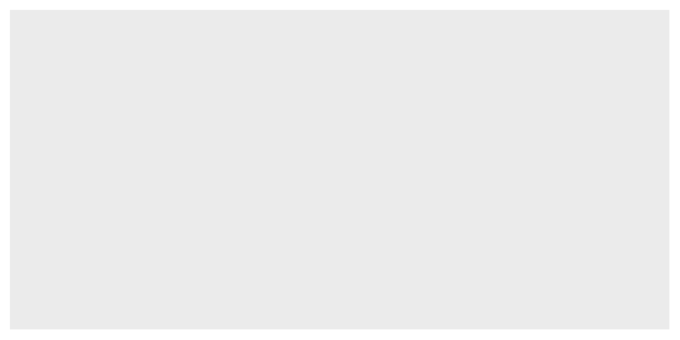

   ```r
   ggplot(data = BlackfootFish_clean)
   ```

   ```r
   ## Creates a blank ggplot(), referencing the BlackfootFish_clean dataset
   ```

2. Define a mapping (using the aesthetic (`aes`) function), by selecting the variables to be plotted and specifying how to present them in the graph, e.g. as x/y positions or characteristics such as size, shape, color, etc.

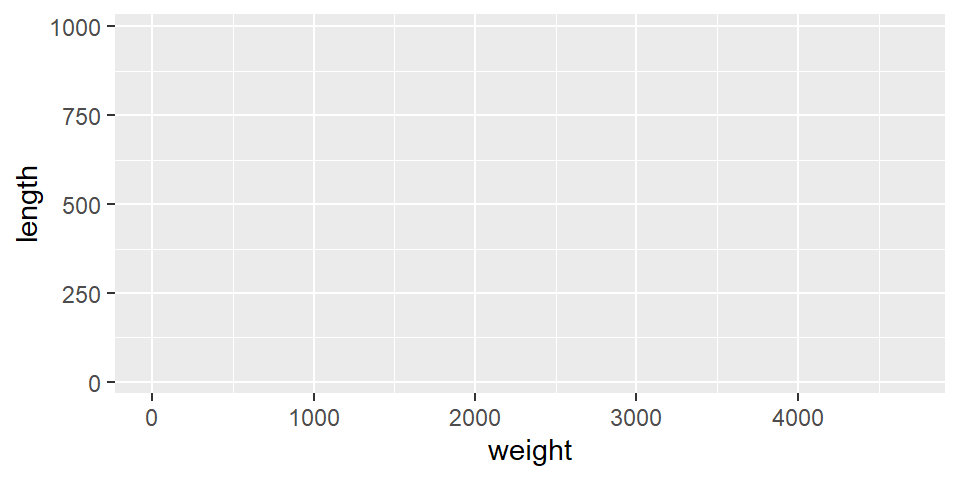

   ```r
   ggplot(data = BlackfootFish_clean,
          mapping = aes(x = weight, y = length))
   ```

   ```r
   #
   # Creates a blank ggplot(), with the variables mapped to the x- and y-axis
   # ggplot() knows where the variables live, since you have defined the data to use
   ```

3. Add “geoms” – graphical representations of the data in the plot (points, lines, bars). **`ggplot2`** offers many different geoms; we will use some common ones today, including:
   - `geom_point()` for scatter plots, dot plots, etc.
   - `geom_boxplot()` for boxplots
   - `geom_bar()` for bar charts
   - `geom_line()` for trend lines, time series, etc.

   To add a geom to the plot use the `+` operator. Because we have two continuous variables in the data, let’s use `geom_point()` first:

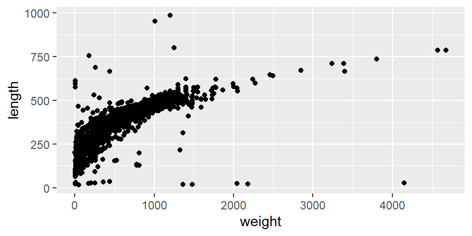

   ```r
   ggplot(data = BlackfootFish_clean,
          mapping = aes(x = weight, y = length)) +
     geom_point()
   ```

   ```r
    # Adds a point for each row (observation) in the data
   ```

You can think of the `+` sign as adding layers to the plot. Each `+` sign must be placed at the end of the line containing the *previous* layer. If, instead, the `+` sign is added at the beginning of the line containing the new layer, **`ggplot2`** will not add the new layer and will return an error message.

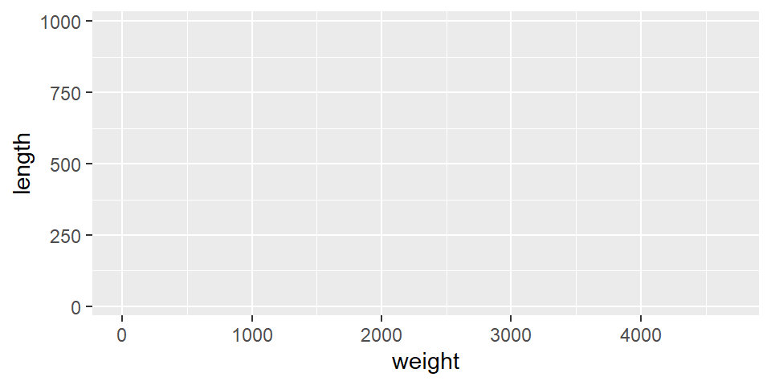

```r
# This will not add the new layer and will return an error message
ggplot(data = BlackfootFish_clean,
           mapping = aes(x = weight, y = length))
```

```r
  + geom_point()
```

```
## Error:
## ! Cannot use `+` with a single argument.
## ℹ Did you accidentally put `+` on a new line?
```

### Building Plots Iteratively

Building plots with **`ggplot2`** is typically an iterative process. We start by defining the dataset we’ll use, lay out the axes, and choose a geom:

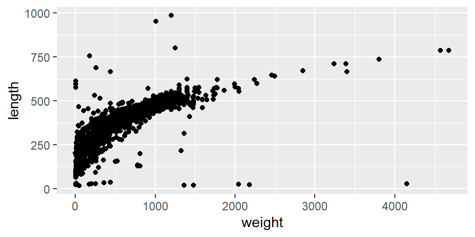

```r
ggplot(data = BlackfootFish_clean,
           mapping = aes(x = weight, y = length)) +
    geom_point()
```

Then, we start modifying this plot to extract more information from it. For instance, we can add transparency (`alpha`) to the points, to avoid overplotting:

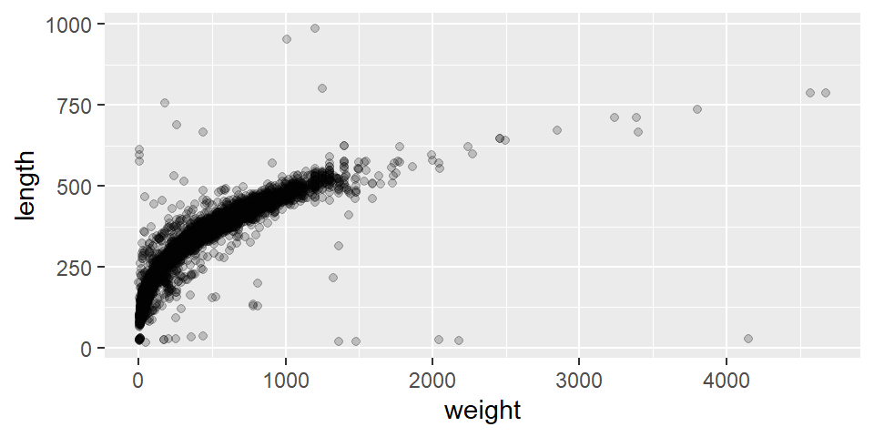

```r
ggplot(data = BlackfootFish_clean,
           mapping = aes(x = weight, y = length)) +
    geom_point(alpha = 0.2)
```

```r
    ## alpha reduces the opacity of the points
    ## 0 is fully transparent
    ## 1 is the original opacity
```

We can also add colors for all the points:

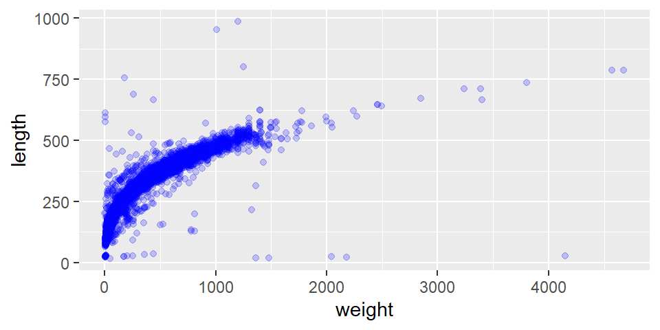

```r
ggplot(data = BlackfootFish_clean,
           mapping = aes(x = weight, y = length)) +
    geom_point(alpha = 0.2, color = "blue")
```

`geom_point` also accepts aesthetics of size and shape. The size of a point is its width in mm. The shape of a point has five different options for plotting:

- an integer [0, 25] of defined plotting characters – same as base `R`
- the name of the shape in quotations (e.g. “circle open” or “diamond filled”)
- a single character, to use that character as a plotting symbol
- a “.” to draw the smallest point that is visible – typically 1 pixel
- an NA, to draw nothing

Reference for shapes in integers and characters:  
https://ggplot2.tidyverse.org/articles/ggplot2-specs.html

### Challenge 6

> Copy and paste the code from the previous code chunk and modify it to assign one of these aesthetics to the `geom_point` aspect of your plot.

> What happened?

```r
## Your ggplot code to answer the challenge goes here!
```

### Piping Data In

Because **`ggplot2`** lives in the `tidyverse`, it is expected to work well with other packages in the `tidyverse`. Because of this, the first argument to creating a `ggplot()` is the dataset you wish to be working with. The pipe operator sends the output of one function directly into the next function, which is useful when you need to do many things to the same dataset. Since the dataset we wish to use is the first argument to `ggplot()`, we can use the pipe operator to pipe the data into the `ggplot()` function!

This would instead look like this:

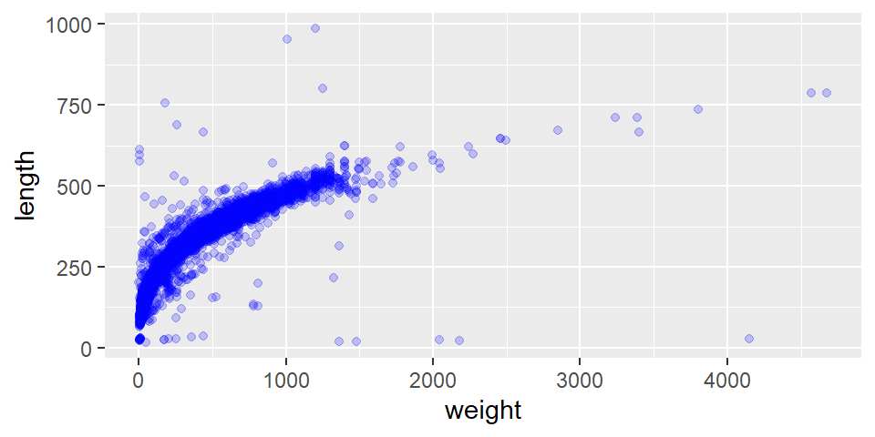

```r
BlackfootFish_clean |>
  ## data to be used in the ggplot
  ggplot(mapping = aes(x = weight, y = length)) +
  ## uses the data piped in as the first argument to ggplot()
    geom_point(alpha = 0.2, color = "blue")
```

Once we pipe the data in, the first argument becomes the `mapping` of the aesthetics. Technically, we are using the name of this argument, which is why it looks like:

`mapping = aes(<VARIABLES>)`

When we pipe our data in, the first argument then becomes this `mapping` argument.

### Assigning More Variables to Aesthetics

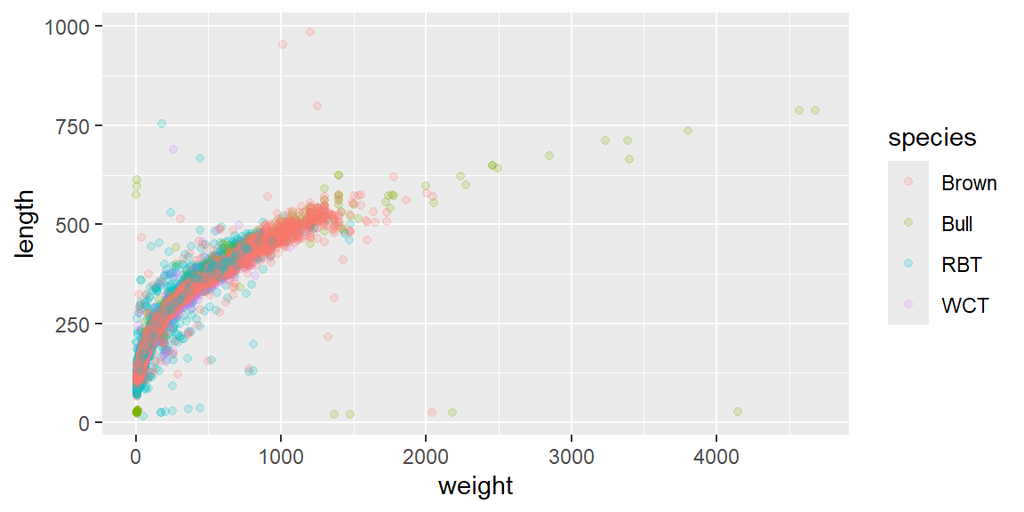

```r
BlackfootFish_clean |>
  ggplot(mapping = aes(x = weight, y = length)) +
    geom_point(alpha = 0.2, aes(color = species))
```

**Note:** When specifying an `alpha` for a scatterplot, it automatically uses that **same** `alpha` in the legend. To remedy this you can add:  
`guides(color = guide_legend(override.aes = list(alpha = 1)))`  
to your plot. This customizes the legend appearance, similar to what we will see in the customization section.

We can also specify the colors directly inside the mapping provided in the `ggplot()` function. This will be seen by **any** geom layers and the mapping will be determined by the x- and y-axis set up in `aes()`.

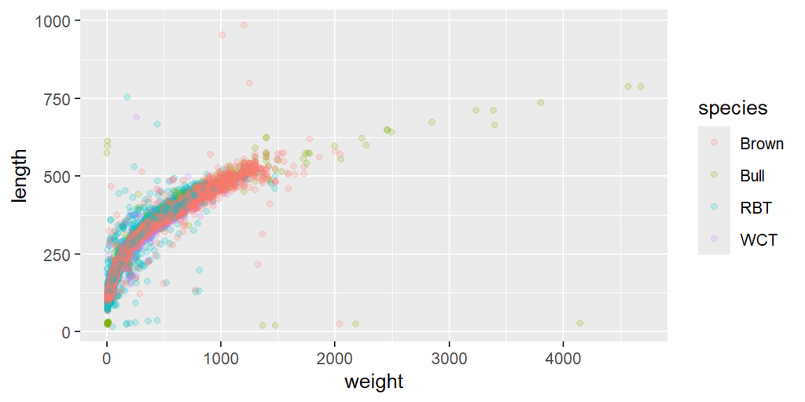

```r
BlackfootFish_clean |>
  ggplot(mapping = aes(x = weight, y = length, color = species)) +
    geom_point(alpha = 0.2)
```

Notice that we can change the geom layer and colors will be still determined by **`species`**

### Local Aesthetics versus Global Aesthetics

When you define aesthetics in the `ggplot()` function, those mappings hold for **every** aspect of your plot.

**Globally**

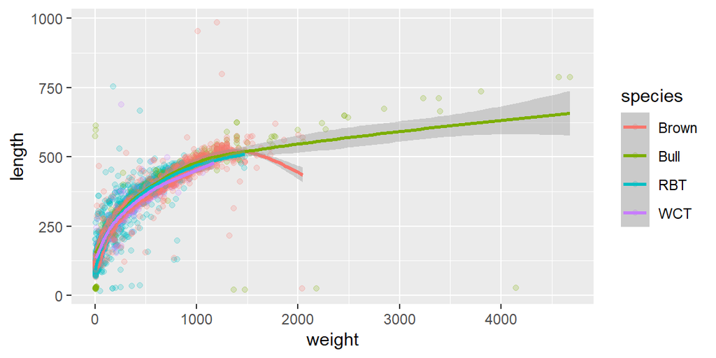

```r
BlackfootFish_clean |>
  ggplot(mapping = aes(x = weight, y = length, color = species)) +
    geom_point(alpha = 0.2) +
  geom_smooth()
```

```r
  ## smoothing line for each species_id -- because color is defined globally
```

**Locally**

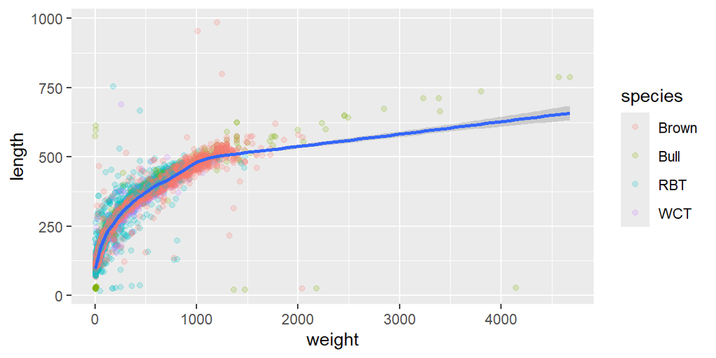

```r
BlackfootFish_clean |>
  ggplot(mapping = aes(x = weight, y = length)) +
  geom_jitter(aes(color = species), alpha = 0.2) +
  geom_smooth()
```

```r
  ## one smoothing line -- no color defined globally
```

### Challenge 7 (Part 1)

> Inspect the `geom_point` help file (either go to https://ggplot2.tidyverse.org/reference/geom_point.html or run `?geom_point`) to see what other aesthetics are available. Map a new variable from the dataset to another aesthetic in your plot. What happened? Does the aesthetic change if you use a continuous variable versus a categorical/discrete variable?

```r
## Your ggplot() code for the challenge goes here!
```

### Challenge 7 (Part 2)

> Use what you just learned to create a scatter plot of `weight` over `year` with data from different years being showed in different colors. Is this a good way to show this type of data?

```r
## Your ggplot() code for the challenge goes here!
```

### Boxplots & Violin Plots

Boxplots provide a visualization of a quantitative variables across different levels of a categorical (grouping) variable. For example, we can use boxplots to visualize the distribution of weight within each species:

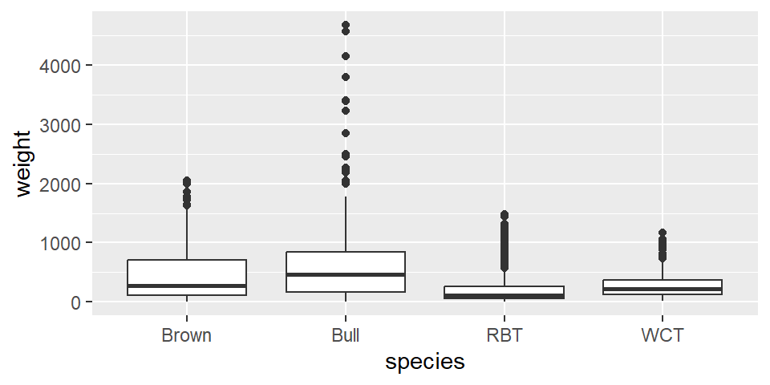

```r
BlackfootFish_clean |>
  ggplot(mapping = aes(x = species, y = weight)) +
    geom_boxplot()
```

By adding points to boxplot, we can have a better idea of the number of measurements and their distribution:

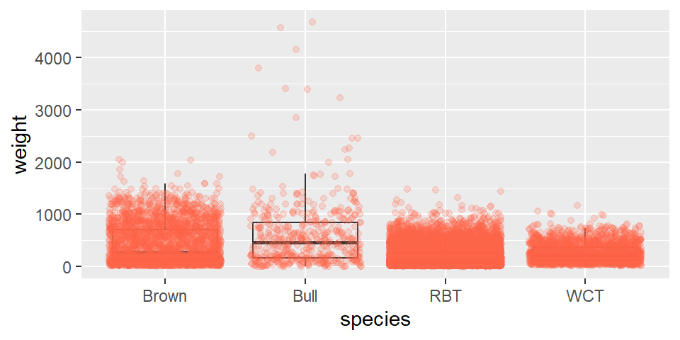

```r
BlackfootFish_clean |>
  ggplot(mapping = aes(x = species, y = weight)) +
    geom_boxplot(alpha = 0) +
    ## alpha = 0 eliminates the black (possible outlier) points, so they're not plotted twice
    geom_jitter(alpha = 0.2, color = "tomato")
```

```r
    ## alpha = 0.2 decreases the opacity of the points, to not be too busy
```

> Notice how the boxplot layer is behind the jitter layer? What would you change in the code to put the boxplot in front of the points?

### Challenge 8 (Part 1)

> Boxplots are useful summaries, but hide details of the *shape* of the distribution. For example, if the distribution is bimodal, we would not see it in a boxplot. A superior density plot is the violin plot, where the shape (of the density of points) is drawn.

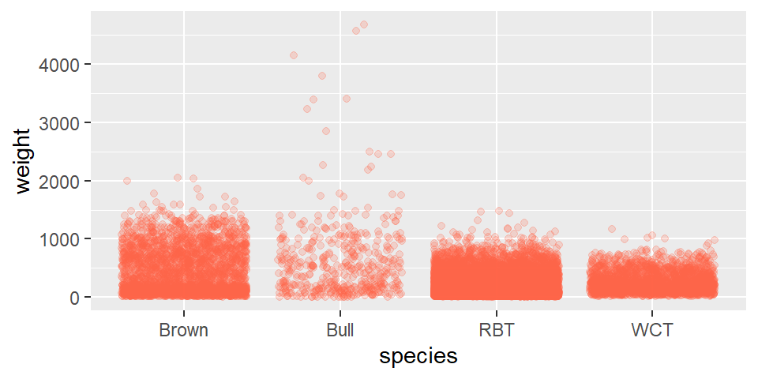

```r
BlackfootFish_clean |>
  ggplot(mapping = aes(x = species, y = weight)) +
  geom_jitter(alpha = 0.2, color = "tomato")
```

```r
##  Start with the boxplot we created
##  1. Replace the boxplot with a violin plot. For help, see geom_violin().
##  You might need to decrease opacity even more to see the violins (try 0.03)
```

### Challenge 8 (Part 2)

> So far, we’ve looked at the distribution of weight within species. Let’s try making a new plot to explore the distribution of another variable within each species.

> Create a boxplot for `length`. This time overlay the boxplot layer over a jitter layer that shows the actual measurements.

```r
##  First: create boxplot for length` overlaid on a jitter layer.
```

### Challenge 8 (Part 3)

> Now, add color to the data points on your boxplot according to the trip the fish was captured on (`trip`).

> *Hint:* Check the class for `trip`. If `trip` was a character instead, how would the graph be different?

```r
## Next: add color to the data points on your boxplot according to the
## the fish was captured on (`trip`)).

## Hint: Check the class for `trip`. If trip was a character instead,
## how would the graph be different?
```

### Bonus violin plot example (DatasauRus)

> The previous example doesn’t fully illustrate the power of violin plots. This example from the `datasauRus` package (https://www.autodeskresearch.com/publications/samestats) shows five different distributions that have exactly the same summary statistics and boxplots but very different shapes:

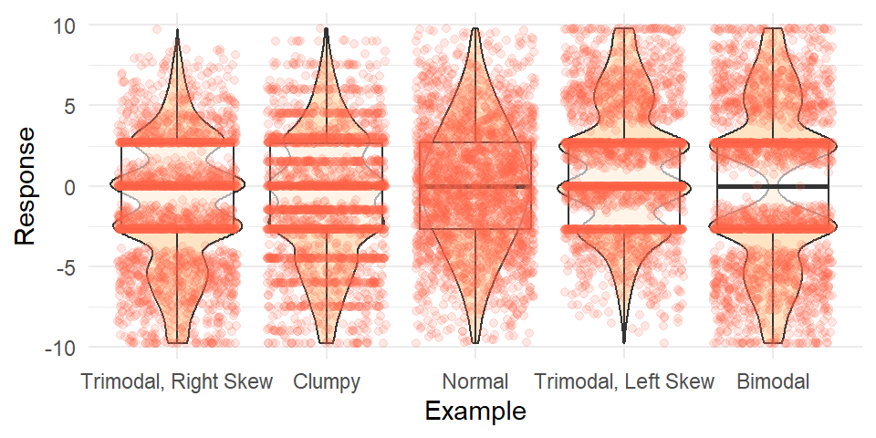

```r
if(!("datasauRus" %in% rownames(installed.packages()))){install.packages("datasauRus")}

library(datasauRus)
data(box_plots)

box_plots_long <- box_plots |>
  pivot_longer(cols=1:5)

box_plots_long <- box_plots_long |>
  rename(Example=name, Response=value)

box_plots_long <- box_plots_long |>
  mutate(Example = factor(Example))

ggplot(box_plots_long, aes(x=Example, y=Response)) +
  geom_violin(fill="bisque") +
  geom_boxplot(alpha=.6) +
  geom_jitter(alpha=0.15, col="tomato") +
  theme_minimal() +
  scale_x_discrete(labels=c('Trimodal, Right Skew', 'Clumpy', 'Normal',
                            'Trimodal, Left Skew',  'Bimodal'))
```

## Plotting Single Variables

### Distribution Plots (Quantitative Variables)

If we wish to visualize the distribution of a single quantitative variable, our plot changes a bit. Unfortunately, the `geom_violin()` function only accepts groups, so we cannot make a violin plot with no groups. Darn it!

But, a violin is simply a density plot that’s been reflected across the y-axis. So, we could likely suffice with a density plot.

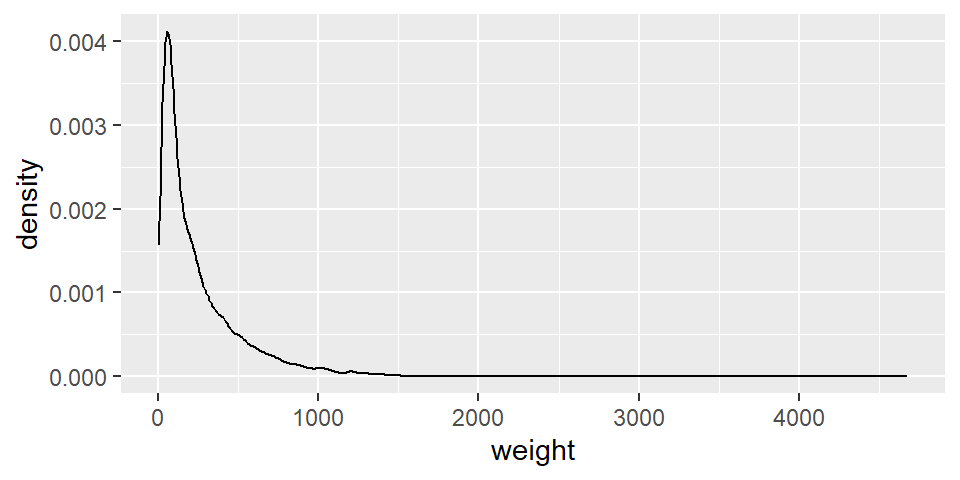

```r
BlackfootFish_clean |>
  ggplot(mapping = aes(x = weight)) +
  geom_density()
```

The default is an empty density plot, which is largely unsatisfying. By adding a `fill = <COLOR>` argument to `geom_density()` we can produce a nicer looking plot:

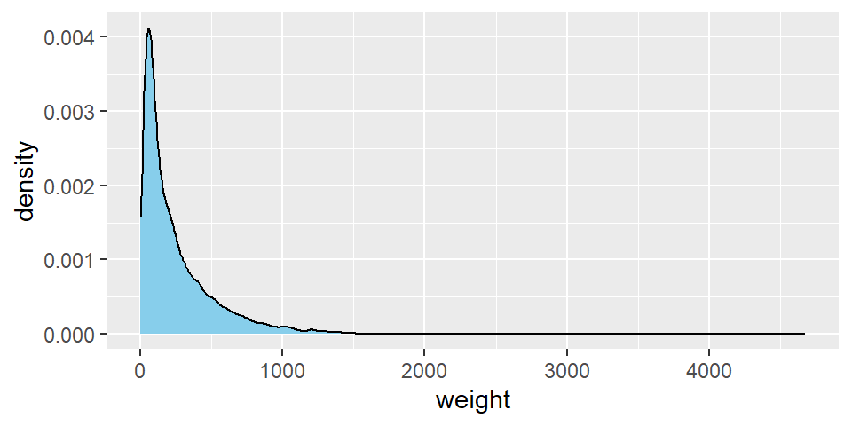

```r
BlackfootFish_clean |>
  ggplot(mapping = aes(x = weight)) +
  geom_density(fill = "sky blue")
```

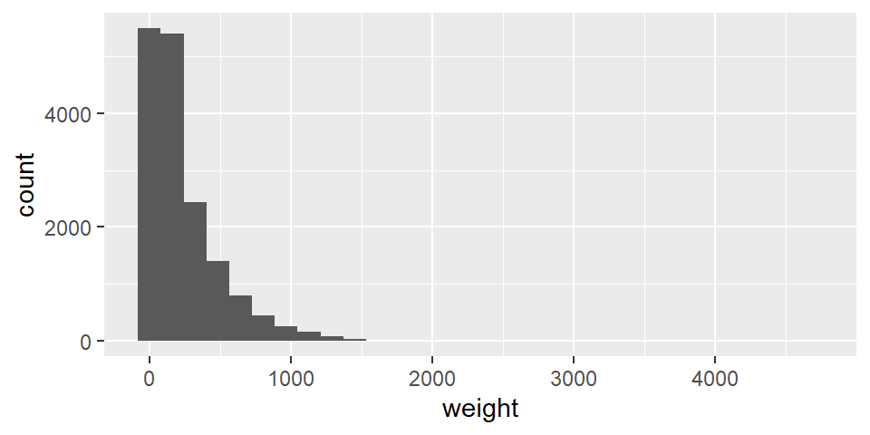

```r
BlackfootFish_clean |>
  ggplot(mapping = aes(x = weight)) +
  geom_histogram()
```

> What warning do you get and why? Do you get an error like this when you use `hist()` in base `R`?

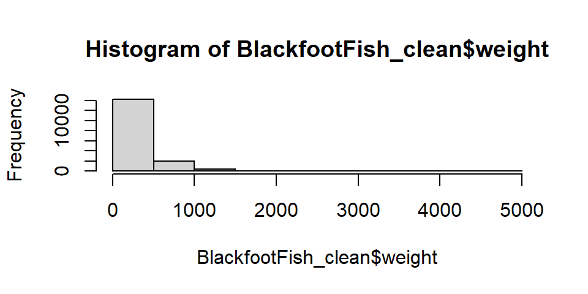

```r
hist(BlackfootFish_clean$weight)
```

There is no single right answer for the number of bins. There are some “plug-in” choices for number of bins that can be used, but you are always welcome to explore different numbers of bins to see if features you are seeing persist when you choose more or less bins.

### Challenge 9

> Use the `bins` argument in `geom_histogram()` to play around with the number of bins in your histogram. Try different numbers of bins to explore how that changes the results!

```r
## Your code to answer the challenge goes here!
```

### Bar Charts (Categorical Variables)

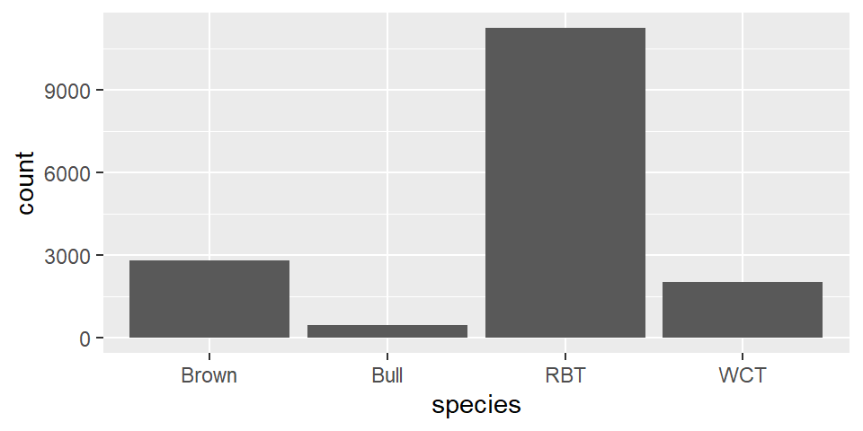

```r
BlackfootFish_clean |>
  ggplot(mapping = aes(x = species)) +
  geom_bar()
```

The x-axis displays the levels of `species`, a variable in the `BlackfootFish_clean` dataset. On the y-axis `count` is displayed, but `count` is **not** a variable in our dataset! Where did `count` come from? Graphs, such as the scatterplots, display the raw values of your data. Other graphs, like bar charts and boxplots, calculate new values (from your data) to plot.

- Bar charts and histograms bin your data and then plot the number of observations that fall in each bin.
- Boxplots find summaries of your data (min, max, quartiles, median) and plot those summaries in a tidy box, with “potential outliers” (data over 1.5*IQR from Q1 or Q3) plotted as points.
- Smoothers (as used in `geom_smooth`) fit a model to your data (you can specify, but we used the `gam` (generalized additive model from the `mgcv` package) default) and then plot the predicted means from that model (with associated 95% confidence intervals).

To calculate each of these summaries of the data, `R` uses a different statistical transformation, or *stat* for short. With a bar chart this looks like the following process:

1. `geom_bar` first looks at the entire data frame
2. `geom_bar` then transforms the data using the `count` statistic
3. the `count` statistic returns a data frame with the number of observations (rows) associated with each level of `species`
4. `geom_bar` uses this summary data frame, to build the plot – levels of `species` are plotted on the x-axis and `count` is plotted on the y-axis

Generally, you can use `geoms` and `stats` interchangeably. This is because every `geom` has a default `stat` and vice versa. For example, the following code produces the same output as above:

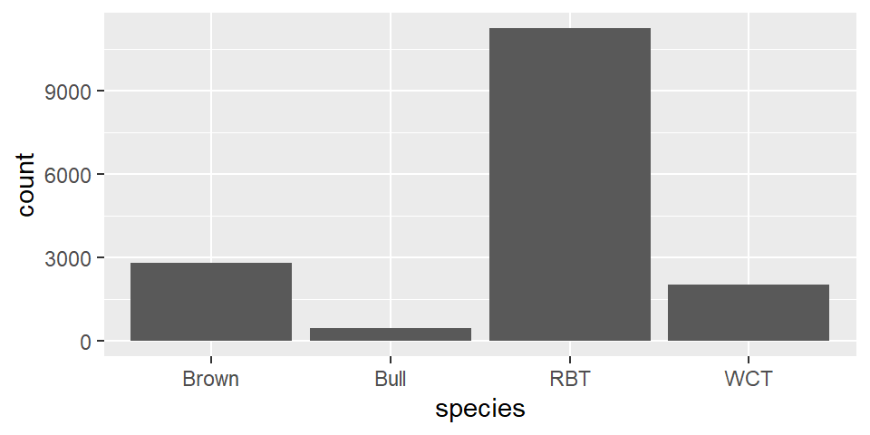

```r
BlackfootFish_clean |>
  ggplot(mapping = aes(x = species)) +
  stat_count()
```

If you so wish, you could override the default `stat` for that `geom`. For example, if you wanted to plot a bar chart of proportions you would use the following code to override the `count` stat:

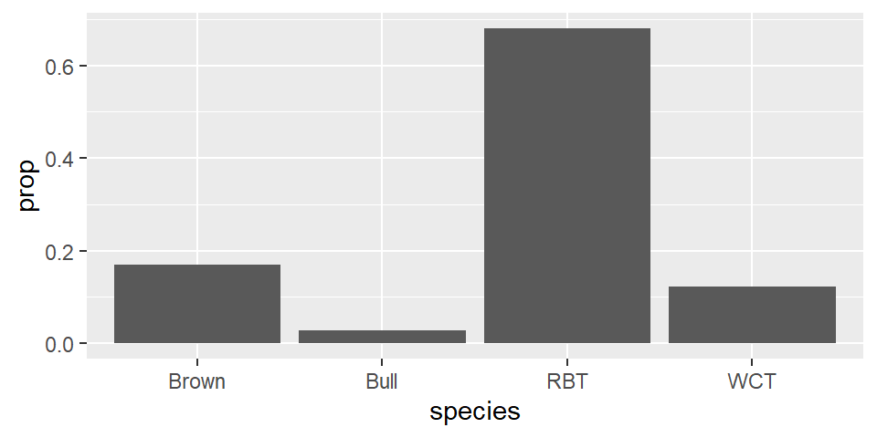

```r
BlackfootFish_clean |>
  ggplot(mapping = aes(x = species)) +
  geom_bar(aes(y = after_stat(prop), group = 1))
```

### Challenge 10

> Why do we need to set `group = 1` in the above proportion bar chart? In other words, what is wrong with the plot below?

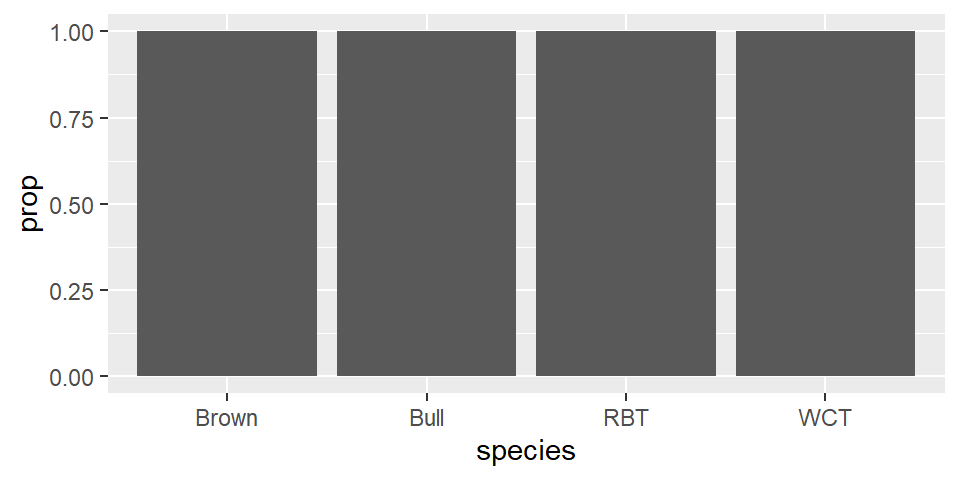

```r
## What is wrong with this plot?
BlackfootFish_clean |>
  ggplot(mapping = aes(x = species)) +
  geom_bar(aes(y = after_stat(prop)))
```

### Colored and/or Stacked Bar Charts

Another piece of visual appeal to creating a bar chart is the ability to use colors to differentiate the different groups, or to plot two different variables in one bar chart (stacked bar chart). Let’s start with adding color to our bar chart.

#### Coloring Bars

As we saw before, to add a color aesthetic to the plot we need to map it to a variable. However, if we use the `color` option that we used before we get a slightly unsatisfying result.

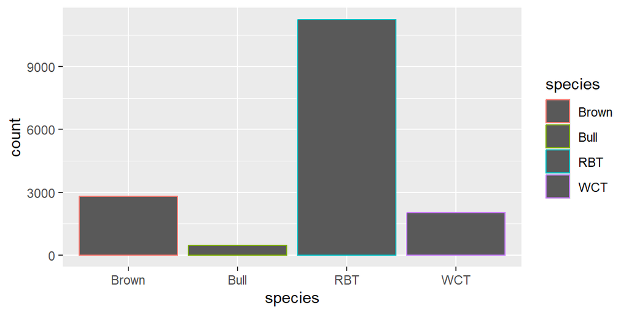

```r
BlackfootFish_clean |>
  ggplot(mapping = aes(x = species, color = species)) +
  geom_bar()
```

We notice that the color only appears in the outline of the bars. For a bar chart, the aesthetic that we are interested in is the `fill` of the bars.

### Challenge 11

> Change the code below so that each bar is filled with a different color.

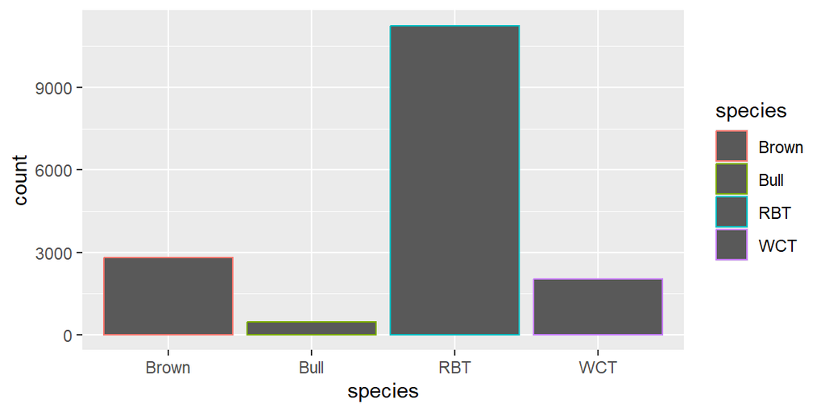

```r
BlackfootFish_clean |>
  ggplot(mapping = aes(x = species, color = species)) +
  geom_bar()
```

#### Stacking Bars

Now suppose you are interested in whether the number of fish captured in different sections of the river differs by species. This would require for you to create a bar plot with two categorical variables. You have two options:

1. each of the bars for section could be stacked within a species *OR*
2. the bars for section could be side-by-side within a species

Let’s see how the two approaches differ. To stack bars of a second categorical variable we would instead use this second categorical variable as the `fill` of the bars. Run these two lines of code and see how they differ.

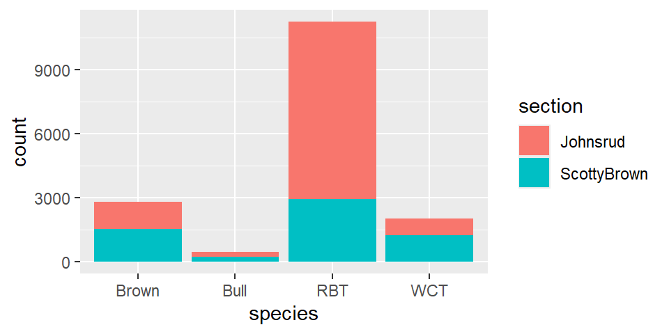

```r
BlackfootFish_clean |>
  ggplot(mapping = aes(x = species, fill = section)) +
  geom_bar()
```

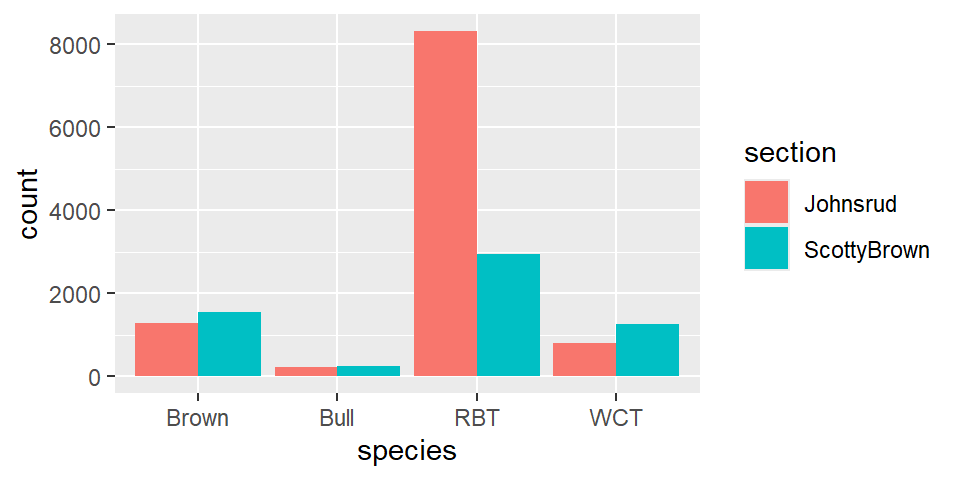

```r
BlackfootFish_clean |>
  ggplot(mapping = aes(x = species, fill = section)) +
  geom_bar(position = "dodge")
```

In the first plot, the position was chosen automatically, but in the second plot the `position` argument was made explicit. What changes did this make in the plots?

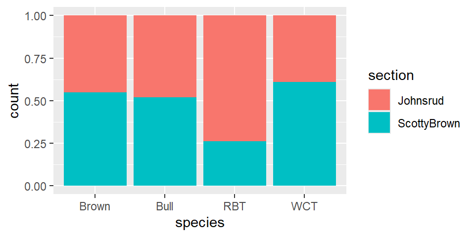

```r
BlackfootFish_clean |>
  ggplot(mapping = aes(x = species, fill = section)) +
  geom_bar(position = "fill")
```

Notice that the y-axis label still says “count” instead of “proportion”. We will learn how to change labels later when we discuss **Customization**.